# Informe-ElPrecioDeLaDiscapacidad

#### Análisis de la economía de las personas discapacitadas.

**1.** En primer lugar importamos los datos con “read_excel” porque tienen la extensión “.xsls”.

```r
library(readxl)

Economia_discapacitados <- read_excel("DATA/Economia discapacitados.xlsx")

View(Economia_discapacitados)
```

**2.** Vamos a comprobar algunas medidas estadísticas de las diferentes columnas del set.

```r
dim(Economia_discapacitados)
```

```
## [1] 19 10
```

```r
class(Economia_discapacitados)
```

```
## [1] "tbl_df"     "tbl"        "data.frame"
```

El set de datos es un tipo de data frame conocido como **tibble**.

Además sabemos que el tibble contiene **19 filas y 10 columnas**, esto es así porque España se compone de 17 comunidades autónomas y 2 cuidades autónomas.

También es conveniente que todos los nombres de las columnas cumplan las reglas sintácticas. En este caso todos los datos de dichas columnas son de tipo “double”.

- **Análisis estadístico general**

```r
summary(Economia_discapacitados, na.rm = TRUE)
```

```
##   Comunidad         Con dificultades para pagar las cosas esenciales
##  Length:19          Min.   :26.40
##  Class :character   1st Qu.:36.65
##  Mode  :character   Median :41.46
##                     Mean   :40.16
##                     3rd Qu.:43.31
##                     Max.   :52.92
##  Ingresos limitados Subida de precios Dificultades para gestionar el dinero
##  Min.   :20.63      Min.   : 8.79     Min.   :0.000
##  1st Qu.:29.94      1st Qu.:11.19     1st Qu.:0.110
##  Median :34.28      Median :13.81     Median :0.420
##  Mean   :33.55      Mean   :13.15     Mean   :0.470
##  3rd Qu.:37.72      3rd Qu.:14.91     3rd Qu.:0.605
##  Max.   :46.16      Max.   :16.82     Max.   :1.840
##  Costes derivados de enfermedad o problema de salud crónico
##  Min.   :0.000
##  1st Qu.:0.915
##  Median :1.210
##  Mean   :1.117
##  3rd Qu.:1.380
##  Max.   :2.110
##  Costes derivados de limitación en actividades básicas Gastos extra inesperados
##  Min.   :0.0000                                        Min.   :2.320
##  1st Qu.:0.1800                                        1st Qu.:3.345
##  Median :0.3700                                        Median :3.970
##  Mean   :0.4342                                        Mean   :3.915
##  3rd Qu.:0.6700                                        3rd Qu.:4.430
##  Max.   :1.0500                                        Max.   :6.010
##  Situación financiera de otro miembro del hogar Otras razones
##  Min.   :2.250                                  Min.   :2.640
##  1st Qu.:3.015                                  1st Qu.:3.755
##  Median :4.360                                  Median :4.500
##  Mean   :4.165                                  Mean   :4.765
##  3rd Qu.:5.345                                  3rd Qu.:5.650
##  Max.   :6.350                                  Max.   :6.940
```

- **Análisis estadístico por columna** Nos centraremos en el analisis de las columnas que hemos considerado más relevantes para nuestro trabajo. En este caso serán las columnas llamadas, “Con dificultades para pagar las cosas esenciales”, “Ingresos limitados”, “Dificultades para gestionar el dinero” y “Costes derivados de enfermedad o problema de salud crónico”

```r
summary(Economia_discapacitados$`Con dificultades para pagar las cosas esenciales`, na.rm = TRUE)
```

```
##    Min. 1st Qu.  Median    Mean 3rd Qu.    Max.
##   26.40   36.65   41.46   40.16   43.31   52.92
```

```r
Economia_discapacitados$`Comunidad`[Economia_discapacitados$`Con dificultades para pagar las cosas esenciales` == min(Economia_discapacitados$`Con dificultades para pagar las cosas esenciales`, na.rm = TRUE)]
```

```
## [1] "País Vasco"
```

```r
Economia_discapacitados$`Comunidad`[Economia_discapacitados$`Con dificultades para pagar las cosas esenciales` == max(Economia_discapacitados$`Con dificultades para pagar las cosas esenciales`, na.rm = TRUE)]
```

```
## [1] "Andalucía"
```

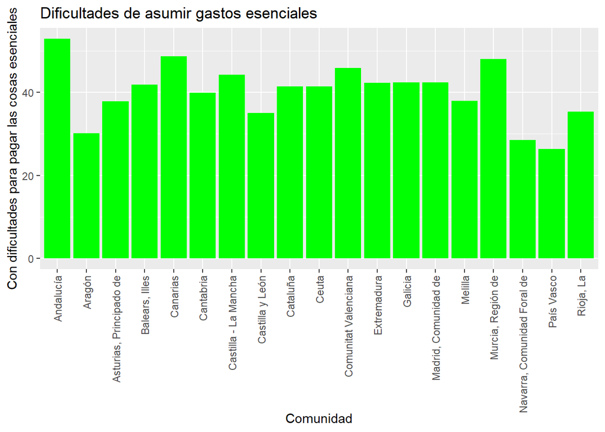

```r
library(tidyverse)
ggplot(data = Economia_discapacitados, aes(x = `Comunidad`, y = `Con dificultades para pagar las cosas esenciales`)) +  geom_bar(stat="identity", position="stack", fill="green") + ggtitle("Dificultades de asumir gastos esenciales") + theme(axis.text.x = element_text(angle = 90, vjust = 0.5, hjust=1))
```

```r
summary(Economia_discapacitados$`Ingresos limitados`, na.rm = TRUE)
```

```
##    Min. 1st Qu.  Median    Mean 3rd Qu.    Max.
##   20.63   29.94   34.28   33.55   37.72   46.16
```

```r
Economia_discapacitados$`Comunidad`[Economia_discapacitados$`Ingresos limitados` == min(Economia_discapacitados$`Ingresos limitados`, na.rm = TRUE)]
```

```
## [1] "País Vasco"
```

```r
Economia_discapacitados$`Comunidad`[Economia_discapacitados$`Ingresos limitados` == max(Economia_discapacitados$`Ingresos limitados`, na.rm = TRUE)]
```

```
## [1] "Andalucía"
```

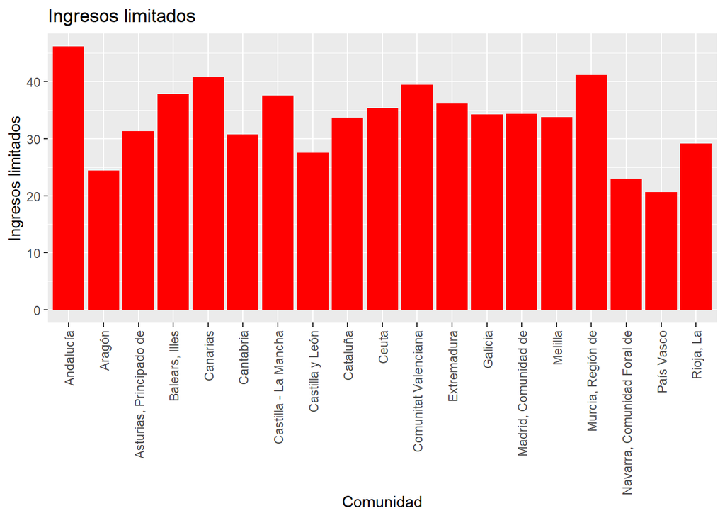

```r
library(tidyverse)
ggplot(data = Economia_discapacitados, aes(x = `Comunidad`, y = `Ingresos limitados`)) +  geom_bar(stat="identity", position="stack", fill="red") + ggtitle("Ingresos limitados") + theme(axis.text.x = element_text(angle = 90, vjust = 0.5, hjust=1))
```

```r
summary(Economia_discapacitados$`Dificultades para gestionar el dinero`, na.rm = TRUE)
```

```
##    Min. 1st Qu.  Median    Mean 3rd Qu.    Max.
##   0.000   0.110   0.420   0.470   0.605   1.840
```

```r
Economia_discapacitados$`Comunidad`[Economia_discapacitados$`Dificultades para gestionar el dinero` == min(Economia_discapacitados$`Dificultades para gestionar el dinero`, na.rm = TRUE)]
```

```
## [1] "Balears, Illes"              "Navarra, Comunidad Foral de"
## [3] "Melilla"
```

```r
Economia_discapacitados$`Comunidad`[Economia_discapacitados$`Dificultades para gestionar el dinero` == max(Economia_discapacitados$`Dificultades para gestionar el dinero`, na.rm = TRUE)]
```

```
## [1] "Asturias, Principado de"
```

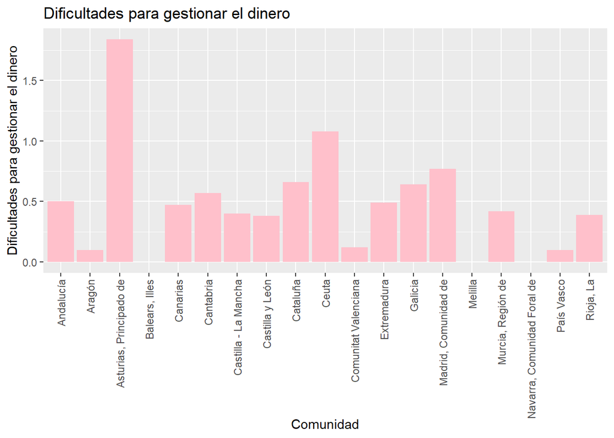

```r
library(tidyverse)
ggplot(data = Economia_discapacitados, aes(x = `Comunidad`, y = `Dificultades para gestionar el dinero`)) +  geom_bar(stat="identity", position="stack", fill="pink")+ ggtitle("Dificultades para gestionar el dinero") + theme(axis.text.x = element_text(angle = 90, vjust = 0.5, hjust=1))
```

```r
summary(Economia_discapacitados$`Costes derivados de enfermedad o problema de salud crónico`, na.rm = TRUE)
```

```
##    Min. 1st Qu.  Median    Mean 3rd Qu.    Max.
##   0.000   0.915   1.210   1.117   1.380   2.110
```

```r
Economia_discapacitados$`Comunidad`[Economia_discapacitados$`Costes derivados de enfermedad o problema de salud crónico` == min(Economia_discapacitados$`Costes derivados de enfermedad o problema de salud crónico`, na.rm = TRUE)]
```

```
## [1] "Ceuta"   "Melilla"
```

```r
Economia_discapacitados$`Comunidad`[Economia_discapacitados$`Costes derivados de enfermedad o problema de salud crónico` == max(Economia_discapacitados$`Costes derivados de enfermedad o problema de salud crónico`, na.rm = TRUE)]
```

```
## [1] "Murcia, Región de"
```

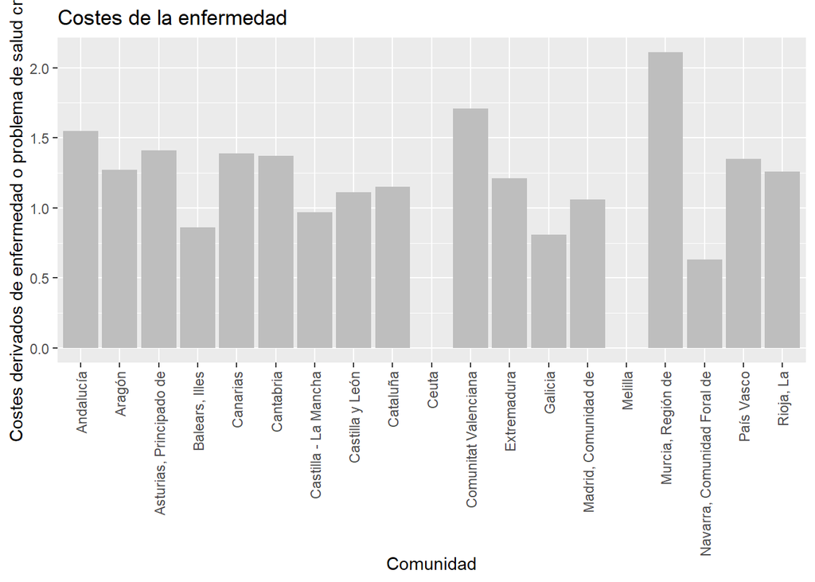

```r
library(tidyverse)
ggplot(data = Economia_discapacitados, aes(x = `Comunidad`, y = `Costes derivados de enfermedad o problema de salud crónico`)) +  geom_bar(stat="identity", position="stack", fill="grey")+ ggtitle("Costes de la enfermedad") + theme(axis.text.x = element_text(angle = 90, vjust = 0.5, hjust=1))
```

- **Conclusiones sobre la economía de las personas con discapacidad**

Aunque hayamos análizado variables completamente diferentes sobre algunos aspectos de la economia de una persona discapacida, podemos sacar una conclusión generalizada de dicha economia a grandes ragos.

Por un lado, es clara la diferneciación a nivel economico en este caso de las personas discapacitadas dependiendo de la comunidad en la que vivan, sobre todo es bastante visible la diferencia entre las comunidades situadas al sur del país y al norte.Ya que en general las del norte tiene mejor economia y menos gastos en el caso de las personas discapacitadas (con la excepción de Ceuta y Melilla).

También es muy destacable en qué comunidades dan mayores facilidades para las personas con discapacidad a nivel financiero. Y es curioso el gran salto que hay entre comunidades de un mismo país. Teniendo en cuenta que la economía de un discapacitado es significativamente relevante para tener una mejor calidad de vida, esto influye en gran medida a su vida en general.

### 3. Relación entre el progreso de las discapacidades y el entorno

#### Número de centros de salud por comunidad.

```r
library(readxl)
Centros_de_salud <- read_excel("DATA/Centros_de_salud.xlsx")
```

```
## * `` -> ...1
```

```r
View(Centros_de_salud)
```

Vamos a analizar las dimensiones de este set de datos.

```r
dim(Centros_de_salud)
```

```
## [1] 18  5
```

```r
class(Centros_de_salud)
```

```
## [1] "tbl_df"     "tbl"        "data.frame"
```

Para poder realizar el análisis de los datos vamos a transformar todos los nombres de las columnas con “make.names” para cumplan las reglas sintácticas. Vamos a realizar este proceso para las columnas “Total_de_centros”, “Centros_de_salud_por_Comunidad”, “Consultorios_locales” y “Tasa_por_100.00_habitantes”.

```r
make.names(Centros_de_salud)
```

```
## [1] "c..Andalucía....Aragón....Asturias..Principado....Balears..Illes....Canarias....Cantabria....Castilla.y.León....Castilla.La.Mancha....Cataluña....Comunitat.Valenciana....Extremadura....Galicia....Madrid.Comunidad.de....Murcia..Región.de....Navarra..C..Foral.de....País.Vasco....Rioja..La....C…
## [2] "c.1517..989..213..162..262..166..3916..1313..1207..852..526..465..424..265..296..322..194..7."
## [3] "c.407..118..69..58..107..42..247..203..418..285..111..398..262..85..59..155..20..7."
## [4] "c.1110..871..144..104..155..124..3669..1110..789..567..415..67..162..180..237..167..174..0."
## [5] "c.18..74.7..20.9..13.5..11.8..28.5..163..64.4..15.9..17..49.5..17.2..6.3..17.7..45.4..14.8..61.7..4.1."
```

```r
Centros_de_salud$Total_de_centros
```

```
##  [1] 1517  989  213  162  262  166 3916 1313 1207  852  526  465  424  265  296
## [16]  322  194    7
```

```r
is.double(Centros_de_salud$Total_de_centros)
```

```
## [1] TRUE
```

```r
typeof(Centros_de_salud$Total_de_centros)
```

```
## [1] "double"
```

```r
make.names(Centros_de_salud)
```

[output not shown]

```r
Centros_de_salud$Centros_de_salud_por_comunidad
```

```
##  [1] 407 118  69  58 107  42 247 203 418 285 111 398 262  85  59 155  20   7
```

```r
is.double(Centros_de_salud$Centros_de_salud_por_comunidad)
```

```
## [1] TRUE
```

```r
typeof(Centros_de_salud$Centros_de_salud_por_comunidad)
```

```
## [1] "double"
```

```r
make.names(Centros_de_salud)
```

[output not shown]

```r
Centros_de_salud$Consultorios_locales
```

```
##  [1] 1110  871  144  104  155  124 3669 1110  789  567  415   67  162  180  237
## [16]  167  174    0
```

```r
is.double(Centros_de_salud$Consultorios_locales)
```

```
## [1] TRUE
```

```r
typeof(Centros_de_salud$Consultorios_locales)
```

```
## [1] "double"
```

```r
make.names(Centros_de_salud)
```

[output not shown]

```r
Centros_de_salud$Tasa_por_100.000_habitantes
```

```
##  [1]  18.0  74.7  20.9  13.5  11.8  28.5 163.0  64.4  15.9  17.0  49.5  17.2
## [13]   6.3  17.7  45.4  14.8  61.7   4.1
```

```r
is.double(Centros_de_salud$Tasa_por_100.000_habitantes)
```

```
## [1] TRUE
```

```r
typeof(Centros_de_salud$Tasa_por_100.000_habitantes)
```

```
## [1] "double"
```

*Vamos a ir analizando cada columna*

**Columna “Total_de_centros”"**

*Media y mediana*

```r
mean(as.double(Centros_de_salud$Total_de_centros), na.rm = TRUE)
```

```
## [1] 727.5556
```

La media del número total de centros de salud por comunidad y/o ciudad autónoma es 727.5556

```r
median(as.double(Centros_de_salud$Total_de_centros), na.rm = TRUE)
```

```
## [1] 373
```

La medina del número de centros de salud por comunidad y/o ciudad autónoma es 373

La mediana de los datos demográficos se distancia mucho de la media, por lo que habrá datos muy extremos.

- **Cálculo conjunto de varias medidas estadísticas (summary)**

```r
summary(as.double(Centros_de_salud$Total_de_centros), na.rm = TRUE)
```

```
##    Min. 1st Qu.  Median    Mean 3rd Qu.    Max.
##     7.0   225.2   373.0   727.6   954.8  3916.0
```

El mínimo es: 7

El máximo es: 3916

El primer cuartil es: 225.2

El tercer cuartil es: 954.8

La mediana: 373

La media es: 727.6

La comunidad con mayor número total de centros es Castilla y León esto se debe a que tiene un gran número de consultorios locales. Podemos relacionar su gran numero de consultorios locales a que es la comunidad con mayor número de municipios, ya que es en la que mas pueblos hay de toda España como ya hemos analizado anteriormente.

El mínimo corresponde a Ceuta y Melilla esto probablemente se debe a que son ciudades, no comunidades y por eso tienen menor población y menor número de centros de salud.

**Columna “Centros_de_salud_por_Comunidad”**

*Media y mediana*

```r
mean(as.double(Centros_de_salud$Centros_de_salud_por_comunidad), na.rm = TRUE)
```

```
## [1] 169.5
```

La media del número de centros de salud por comunidad y/o ciudad autónoma es 169.5

```r
median(as.double(Centros_de_salud$Centros_de_salud_por_comunidad), na.rm = TRUE)
```

```
## [1] 114.5
```

La medina del número de centros de salud por comunidad y/o ciudad autónoma es 114.5

La mediana de los datos demográficos no se distancia mucho de la media, por lo que no habrá datos muy extremos.

- **Cálculo conjunto de varias medidas estadísticas (summary)**

```r
summary(as.double(Centros_de_salud$Centros_de_salud_por_comunidad), na.rm = TRUE)
```

```
##    Min. 1st Qu.  Median    Mean 3rd Qu.    Max.
##     7.0    61.5   114.5   169.5   258.2   418.0
```

El mínimo es: 7

El máximo es: 418

El primer cuartil es: 61.5

El tercer cuartil es: 258.2

La mediana: 114.5

La media es: 169.5

La comunidad con mayor número de centros de salud es Cataluña que es una de las comunidades con mayor densidad demográfica.

El mínimo corresponde a Ceuta y Melilla esto probablemente se debe a que son ciudades, no comunidades y por eso tienen menor población y menor número de centros de salud.

**Columna “Consultorios_locales”**

*Media y mediana*

```r
mean(as.double(Centros_de_salud$Consultorios_locales), na.rm = TRUE)
```

```
## [1] 558.0556
```

La media del número de centros de salud por comunidad y/o ciudad autónoma es 558.0556

```r
median(as.double(Centros_de_salud$Consultorios_locales), na.rm = TRUE)
```

```
## [1] 177
```

La medina del número de centros de salud por comunidad y/o ciudad autónoma es 177

La mediana de los datos demográficos se distancia mucho de la media, por lo que habrá datos muy extremos.

- **Cálculo conjunto de varias medidas estadísticas (summary)**

```r
summary(as.double(Centros_de_salud$Consultorios_locales), na.rm = TRUE)
```

```
##    Min. 1st Qu.  Median    Mean 3rd Qu.    Max.
##     0.0   146.8   177.0   558.1   733.5  3669.0
```

El mínimo es: 0

El máximo es: 3669

El primer cuartil es: 146.8

La comunidad con mayor número de consultorios locales es Castilla y León que es la comunidad con mayor número de pueblos y, por eso, tiene un gran número de consultorios locales.

El mínimo corresponde a Ceuta y Melilla esto se debe a que son ciudades y en las ciudades no hay consultorios locales, hay centros de salud.

**Columna “Tasa_por_100.000_habitantes”**

*Media y mediana*

```r
mean(as.double(Centros_de_salud$Tasa_por_100.000_habitantes), na.rm = TRUE)
```

```
## [1] 35.8
```

La media del número de centros de salud por comunidad y/o ciudad autónoma es 35.8

```r
median(as.double(Centros_de_salud$Tasa_por_100.000_habitantes), na.rm = TRUE)
```

```
## [1] 17.85
```

La medina del número de centros de salud por comunidad y/o ciudad autónoma es 17.85

La mediana de los datos demográficos se distancia mucho de la media, por lo que habrá datos muy extremos.

- **Cálculo conjunto de varias medidas estadísticas (summary)**

```r
summary(as.double(Centros_de_salud$Tasa_por_100.000_habitantes), na.rm = TRUE)
```

```
##    Min. 1st Qu.  Median    Mean 3rd Qu.    Max.
##    4.10   15.07   17.85   35.80   48.48  163.00
```

El mínimo es: 4.1

El máximo es: 163

El primer cuartil es: 15.07

La mediana: 17.85

La media es: 35.8

La comunidad con mayor tasa por 100.000 habitantes de centors de salud y consultorios locales es Castilla y León que es la comunidad con mayor número de pueblos y, por eso, tiene un gran número de consultorios locales.

El mínimo corresponde a Ceuta y Melilla esto puede deberse a que el hecho de estar fuera de la península tienen una mayor falta de recursos y ayudas por parte del Estado.

- **Gráfico centros de salud**

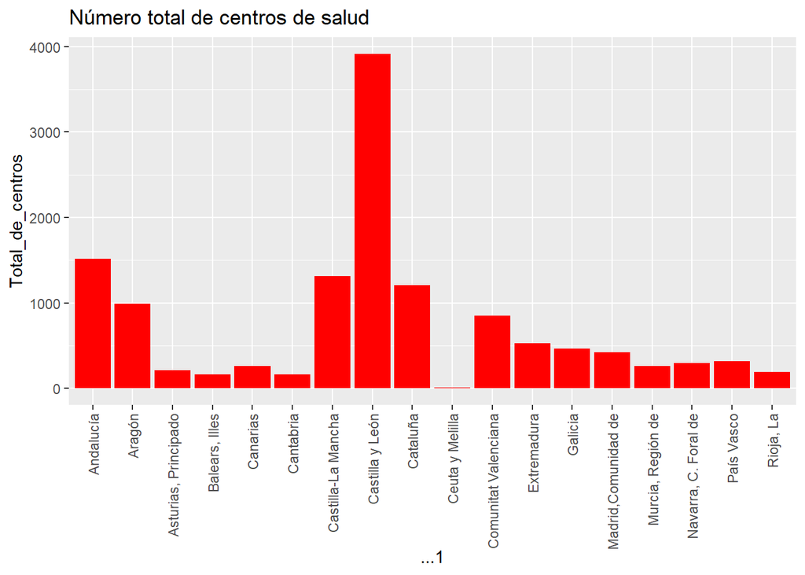

```r
library(tidyverse)
ggplot(data = Centros_de_salud, aes(x = `...1`, y = `Total_de_centros`)) +  geom_bar(stat="identity", position="stack", fill="red") + ggtitle("Número total de centros de salud") + theme(axis.text.x = element_text(angle = 90, vjust = 0.5, hjust=1))
```

- **Conclusiones centros de salud**

Fundamentalmente podemos ver que la cantidad de los centros de salud por comunidad autónoma depende de la cantidad de localidades que tenga la propia comunidad. Por ello, Castilla y León y Andalucia presentan los valores máximos.

No podemos inferir ninguna relación con respecto a que el hecho de tener más centros de salud suponga una mayor calidad de la asistencia sanitaria. De hecho probablemente sea al contrario, considerando que todos los habitantes tienen que tener disponible algún centro sanitario cerca de su domicilio, cuanto más centralizada este la asistencia más calidad tendrán los equipos disponibles.

#### Limitaciones en la vida cotidiana.

**1.** En primer lugar importamos los datos con “read_excel” porque tienen la extensión “.xsls”.

```r
library(readxl)

Limitaciones_vida_cotidiana <- read_excel("DATA/Limitaciones vida cotidiana.xlsx")

View(Limitaciones_vida_cotidiana)
```

**2.** Vamos a comprobar algunas medidas estadísticas con la información recogidos en las distintas columnas

```r
dim(Limitaciones_vida_cotidiana)
```

```
## [1] 19  7
```

```r
class(Limitaciones_vida_cotidiana)
```

```
## [1] "tbl_df"     "tbl"        "data.frame"
```

El set de datos es un tipo de data frame conocido como **tibble**.

Además sabemos que el tibble contiene **19 filas y 7 columnas**, esto es así porque España se compone de 17 comunidades autónomas y 2 cuidades autónomas.

También es conveniente transformar todos los nombres de la columna con “make.names” para cumplan las reglas sintácticas.

```r
make.names(Limitaciones_vida_cotidiana)
```

```
## [1] "c..Andalucía....Aragón....Asturias..Principado.de....Balears..Illes....Canarias....Cantabria....Castilla.y.León....Castilla...La.Mancha....Cataluña....Comunitat.Valenciana....Extremadura....Galicia....Madrid..Comunidad.de....Murcia..Región.de....Navarra..Comunidad.Foral.de....País.Vasco....R…
## [2] "c.3.4..1.69..3.13..0.87..1.63..1.67..2.09..2.86..2.56..2.65..1.56..2.08..1.84..3.31..1.87..2.07..1.43..1.96..1.23."
## [3] "c.3.08..1.56..2.68..2.58..0.69..2.77..3.19..2.17..3.16..2.46..1.64..3.26..1.75..3.14..2.61..2.29..2.53..3.51..2.74."
## [4] "c.4.9..3.92..3.76..2.54..2.98..2.53..4.24..5.43..3.93..3.33..1.68..3.78..2.91..3.42..1.84..2.83..2.9..4.89..6.16."
## [5] "c.2.54..1.7..1.89..2.04..1.13..1.13..1.22..1.35..2.07..1.63..1.45..2.71..1.09..1.36..0.69..1.66..1.7..0.39..0.35."
## [6] "c.5.91..6.93..4.96..3.01..6.11..5.84..5.02..7.03..6.17..5.83..4.6..7.1..4.66..6.86..4.11..5.89..5.83..6.38..5.55."
## [7] "c.1.96..1.26..1.48..2.63..1.35..1.9..1.46..2.24..2.62..1.95..0.99..1.99..1.16..2.92..0.58..1.6..1.77..3.09..0.35."
```

```r
Limitaciones_vida_cotidiana$`Para cocinar`
```

```
##  [1] 3.40 1.69 3.13 0.87 1.63 1.67 2.09 2.86 2.56 2.65 1.56 2.08 1.84 3.31 1.87
## [16] 2.07 1.43 1.96 1.23
```

```r
is.double(Limitaciones_vida_cotidiana$`Para cocinar`)
```

```
## [1] TRUE
```

```r
typeof(Limitaciones_vida_cotidiana$`Para cocinar`)
```

```
## [1] "double"
```

Los datos de todas las columnsa son de tipo “double”.

- **Análisis estadístico general**

```r
summary(Limitaciones_vida_cotidiana, na.rm = TRUE)
```

```
##   Comunidad          Para cocinar   Para usar el teléfono Para realizar compras
##  Length:19          Min.   :0.870   Min.   :0.690         Min.   :1.680
##  Class :character   1st Qu.:1.650   1st Qu.:2.230         1st Qu.:2.865
##  Mode  :character   Median :1.960   Median :2.610         Median :3.420
##                     Mean   :2.100   Mean   :2.516         Mean   :3.577
##                     3rd Qu.:2.605   3rd Qu.:3.110         3rd Qu.:4.085
##                     Max.   :3.400   Max.   :3.510         Max.   :6.160
##  Para administrar los medicamentos Para realizar tareas domésticas
##  Min.   :0.350                     Min.   :3.010
##  1st Qu.:1.130                     1st Qu.:4.990
##  Median :1.450                     Median :5.840
##  Mean   :1.479                     Mean   :5.673
##  3rd Qu.:1.795                     3rd Qu.:6.275
##  Max.   :2.710                     Max.   :7.100
##  Para ocuparse de los trámites administrativos diarios
##  Min.   :0.350
##  1st Qu.:1.305
##  Median :1.770
##  Mean   :1.753
##  3rd Qu.:2.115
##  Max.   :3.090
```

```r
Media_cocinar <- mean(Limitaciones_vida_cotidiana$`Para cocinar`, na.rm=TRUE)

Media_cocinar
```

```
## [1] 2.1
```

```r
Media_tfno <- mean(Limitaciones_vida_cotidiana$`Para usar el teléfono`, na.rm=TRUE)

Media_tfno
```

```
## [1] 2.516316
```

```r
Media_compras <- mean(Limitaciones_vida_cotidiana$`Para realizar compras`, na.rm=TRUE)

Media_compras
```

```
## [1] 3.577368
```

```r
Media_medicamentos <- mean(Limitaciones_vida_cotidiana$`Para administrar los medicamentos`, na.rm=TRUE)

Media_medicamentos
```

```
## [1] 1.478947
```

```r
Media_tareas <- mean(Limitaciones_vida_cotidiana$`Para realizar tareas domésticas`, na.rm=TRUE)

Media_tareas
```

```
## [1] 5.673158
```

```r
Media_tramites <- mean(Limitaciones_vida_cotidiana$`Para ocuparse de los trámites administrativos diarios`, na.rm=TRUE)

Media_tramites
```

```
## [1] 1.752632
```

```r
Medias <- c(Media_cocinar, Media_tfno, Media_compras, Media_medicamentos, Media_tareas, Media_tramites)

max(Medias, na.rm=TRUE)
```

```
## [1] 5.673158
```

```r
Medias[max(Medias, na.rm=TRUE)]
```

```
## [1] 5.673158
```

Comparando la media de todas las limitaciones descritas vemos que la mayor problemática, en líneas generales, para las personas discapacitadas viene a la hora de realizar las tareas domésticas.

- **Análisis estadístico por columnas**

```r
summary(Limitaciones_vida_cotidiana$`Para cocinar`, na.rm = TRUE)
```

```
##    Min. 1st Qu.  Median    Mean 3rd Qu.    Max.
##   0.870   1.650   1.960   2.100   2.605   3.400
```

```r
Limitaciones_vida_cotidiana$`Comunidad`[Limitaciones_vida_cotidiana$`Para cocinar`== min(Limitaciones_vida_cotidiana$`Para cocinar`, na.rm = TRUE)]
```

```
## [1] "Balears, Illes"
```

```r
Limitaciones_vida_cotidiana$`Comunidad`[Limitaciones_vida_cotidiana$`Para cocinar` == max(Limitaciones_vida_cotidiana$`Para cocinar`, na.rm = TRUE)]
```

```
## [1] "Andalucía"
```

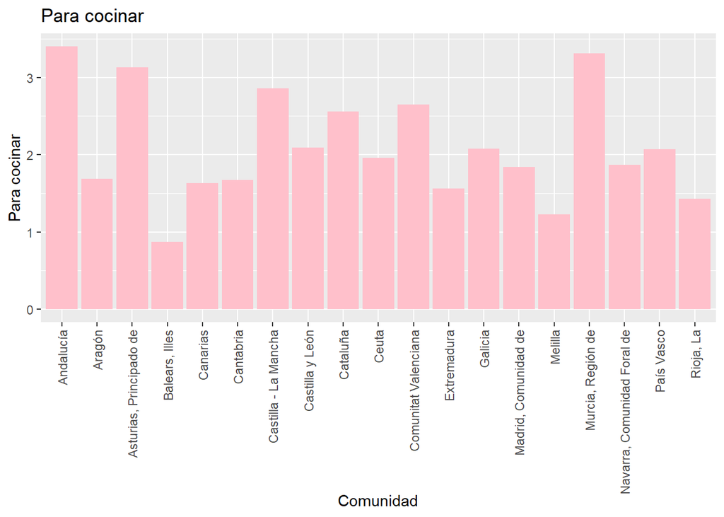

```r
library(tidyverse)
ggplot(data = Limitaciones_vida_cotidiana, aes(x = `Comunidad`, y = `Para cocinar`)) +  geom_bar(stat="identity", position="stack", fill="pink") + ggtitle("Para cocinar") + theme(axis.text.x = element_text(angle = 90, vjust = 0.5, hjust=1))
```

Con respecto a las limitaciones para cocinar, las Islas Baleares presentan la tasa más baja, mientras que Andalucía presenta valores más altos. Fijándonos en las comunidades más significativas, podríamos visualizar que el las zonas más rurales los discapacitados parece que tienen menos dificultades para cocinar.

```r
summary(Limitaciones_vida_cotidiana$`Para realizar compras`, na.rm = TRUE)
```

```
##    Min. 1st Qu.  Median    Mean 3rd Qu.    Max.
##   1.680   2.865   3.420   3.577   4.085   6.160
```

```r
Limitaciones_vida_cotidiana$`Comunidad`[Limitaciones_vida_cotidiana$`Para realizar compras`== min(Limitaciones_vida_cotidiana$`Para realizar compras`, na.rm = TRUE)]
```

```
## [1] "Extremadura"
```

```r
Limitaciones_vida_cotidiana$`Comunidad`[Limitaciones_vida_cotidiana$`Para realizar compras` == max(Limitaciones_vida_cotidiana$`Para realizar compras`, na.rm = TRUE)]
```

```
## [1] "Melilla"
```

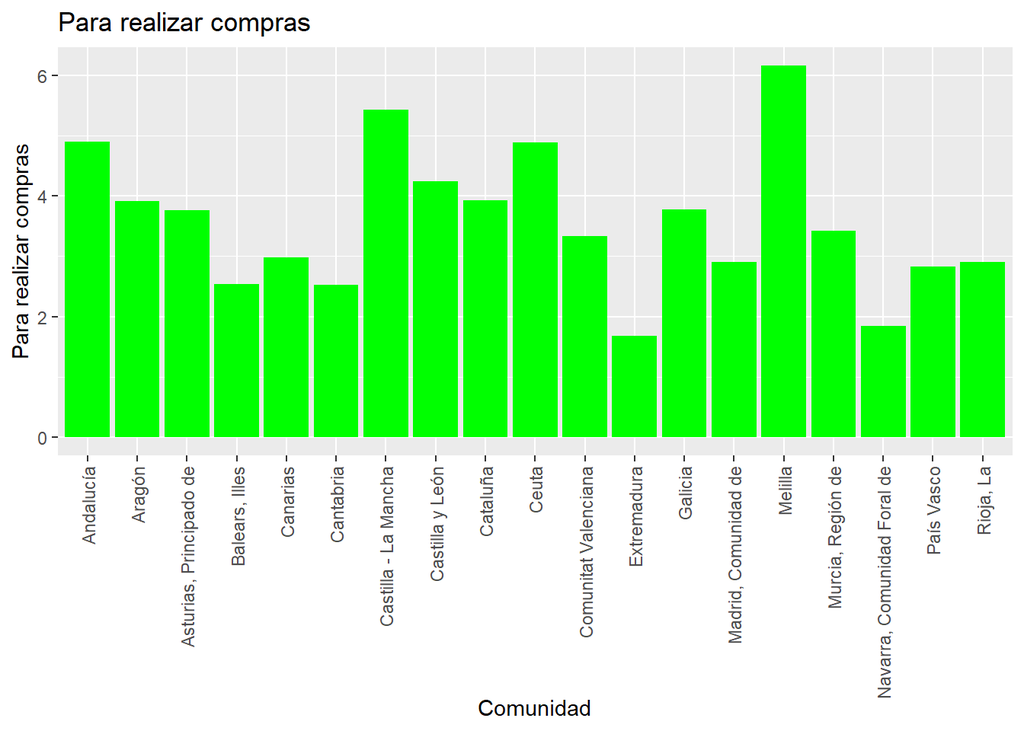

```r
library(tidyverse)
ggplot(data = Limitaciones_vida_cotidiana, aes(x = `Comunidad`, y = `Para realizar compras`)) +  geom_bar(stat="identity", position="stack", fill="green") + ggtitle("Para realizar compras") + theme(axis.text.x = element_text(angle = 90, vjust = 0.5, hjust=1))
```

Con respecto a las limitaciones para hacer compras, Extremadura presenta la tasa más baja, mientras que Melilla presenta valores más altos. No hay ninguna diferencia apreciable a simple vista entre las zonas rurales y las zonas urbanas.

```r
summary(Limitaciones_vida_cotidiana$`Para usar el teléfono`, na.rm = TRUE)
```

```
##    Min. 1st Qu.  Median    Mean 3rd Qu.    Max.
##   0.690   2.230   2.610   2.516   3.110   3.510
```

```r
Limitaciones_vida_cotidiana$`Comunidad`[Limitaciones_vida_cotidiana$`Para usar el teléfono`== min(Limitaciones_vida_cotidiana$`Para usar el teléfono`, na.rm = TRUE)]
```

```
## [1] "Canarias"
```

```r
Limitaciones_vida_cotidiana$`Comunidad`[Limitaciones_vida_cotidiana$`Para usar el teléfono` == max(Limitaciones_vida_cotidiana$`Para usar el teléfono`, na.rm = TRUE)]
```

```
## [1] "Ceuta"
```

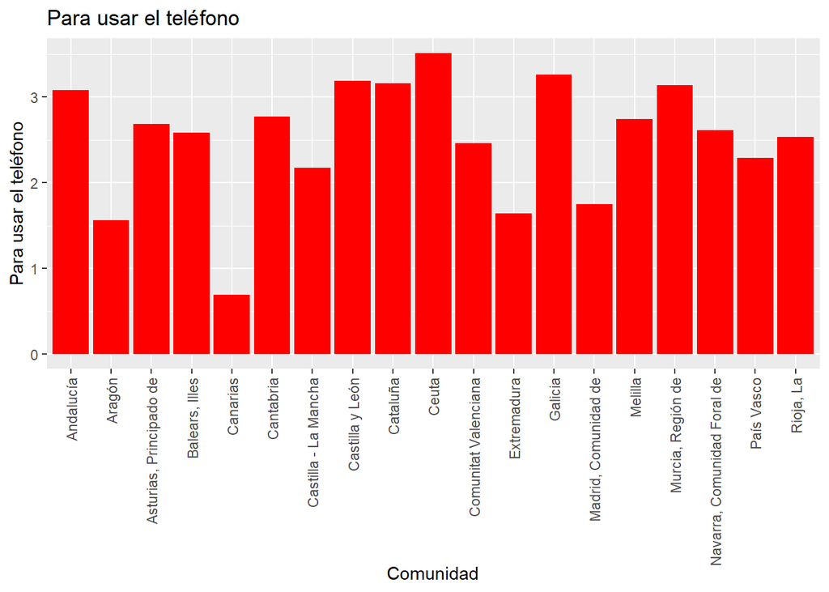

```r
library(tidyverse)
ggplot(data = Limitaciones_vida_cotidiana, aes(x = `Comunidad`, y = `Para usar el teléfono`)) +  geom_bar(stat="identity", position="stack", fill="red") + ggtitle("Para usar el teléfono") + theme(axis.text.x = element_text(angle = 90, vjust = 0.5, hjust=1))
```

Con respecto a las limitaciones para usar el teléfono, Canarias presenta la tasa más baja, mientras que Ceuta presenta valores más altos. No hay ninguna diferencia apreciable a simple vista entre las zonas rurales y las zonas urbanas.

```r
summary(Limitaciones_vida_cotidiana$`Para administrar los medicamentos`, na.rm = TRUE)
```

```
##    Min. 1st Qu.  Median    Mean 3rd Qu.    Max.
##   0.350   1.130   1.450   1.479   1.795   2.710
```

```r
Limitaciones_vida_cotidiana$`Comunidad`[Limitaciones_vida_cotidiana$`Para administrar los medicamentos`== min(Limitaciones_vida_cotidiana$`Para administrar los medicamentos`, na.rm = TRUE)]
```

```
## [1] "Melilla"
```

```r
Limitaciones_vida_cotidiana$`Comunidad`[Limitaciones_vida_cotidiana$`Para administrar los medicamentos` == max(Limitaciones_vida_cotidiana$`Para administrar los medicamentos`, na.rm = TRUE)]
```

```
## [1] "Galicia"
```

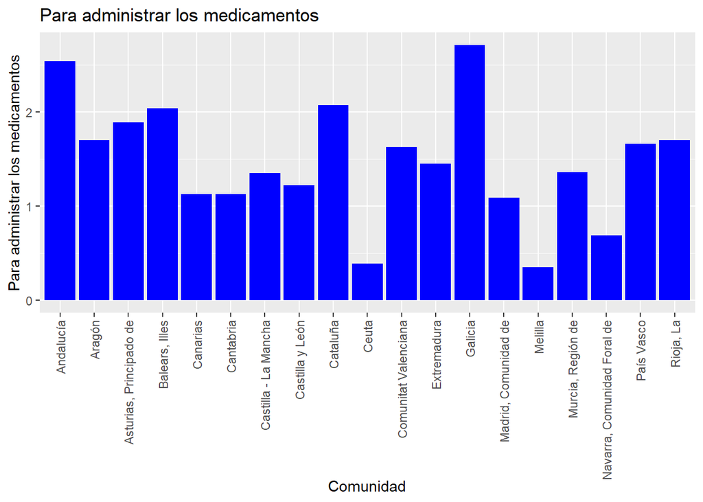

```r
library(tidyverse)
ggplot(data = Limitaciones_vida_cotidiana, aes(x = `Comunidad`, y = `Para administrar los medicamentos`)) +  geom_bar(stat="identity", position="stack", fill="blue") + ggtitle("Para administrar los medicamentos") + theme(axis.text.x = element_text(angle = 90, vjust = 0.5, hjust=1))
```

Con respecto a las limitaciones para administrar los medicamentos, Melilla presenta la tasa más baja, mientras que Galicia presenta valores más altos. No hay ninguna diferencia apreciable a simple vista entre las zonas rurales y las zonas urbanas.

```r
summary(Limitaciones_vida_cotidiana$`Para realizar tareas domésticas`, na.rm = TRUE)
```

```
##    Min. 1st Qu.  Median    Mean 3rd Qu.    Max.
##   3.010   4.990   5.840   5.673   6.275   7.100
```

```r
Limitaciones_vida_cotidiana$`Comunidad`[Limitaciones_vida_cotidiana$`Para realizar tareas domésticas`== min(Limitaciones_vida_cotidiana$`Para realizar tareas domésticas`, na.rm = TRUE)]
```

```
## [1] "Balears, Illes"
```

```r
Limitaciones_vida_cotidiana$`Comunidad`[Limitaciones_vida_cotidiana$`Para realizar tareas domésticas` == max(Limitaciones_vida_cotidiana$`Para realizar tareas domésticas`, na.rm = TRUE)]
```

```
## [1] "Galicia"
```

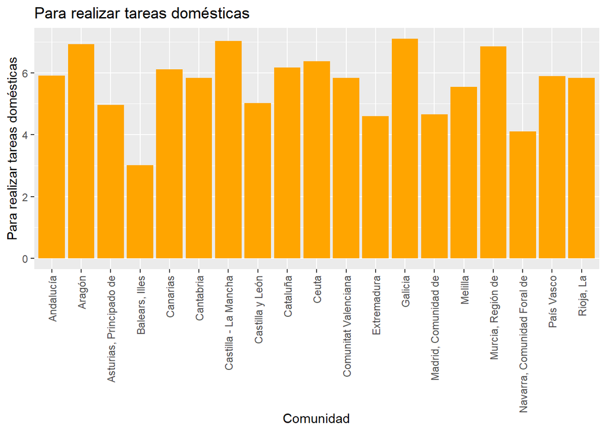

```r
library(tidyverse)
ggplot(data = Limitaciones_vida_cotidiana, aes(x = `Comunidad`, y = `Para realizar tareas domésticas`)) +  geom_bar(stat="identity", position="stack", fill="orange") + ggtitle("Para realizar tareas domésticas") + theme(axis.text.x = element_text(angle = 90, vjust = 0.5, hjust=1))
```

Con respecto a las limitaciones para realizar las tareas domésticas, las Islas Baleares presentan la tasa más baja, mientras que Galicia presenta valores más altos. No hay ninguna diferencia apreciable a simple vista entre las zonas rurales y las zonas urbanas.

```r
summary(Limitaciones_vida_cotidiana$`Para ocuparse de los trámites administrativos diarios`, na.rm = TRUE)
```

```
##    Min. 1st Qu.  Median    Mean 3rd Qu.    Max.
##   0.350   1.305   1.770   1.753   2.115   3.090
```

```r
Limitaciones_vida_cotidiana$`Comunidad`[Limitaciones_vida_cotidiana$`Para ocuparse de los trámites administrativos diarios`== min(Limitaciones_vida_cotidiana$`Para ocuparse de los trámites administrativos diarios`, na.rm = TRUE)]
```

```
## [1] "Melilla"
```

```r
Limitaciones_vida_cotidiana$`Comunidad`[Limitaciones_vida_cotidiana$`Para ocuparse de los trámites administrativos diarios` == max(Limitaciones_vida_cotidiana$`Para ocuparse de los trámites administrativos diarios`, na.rm = TRUE)]
```

```
## [1] "Ceuta"
```

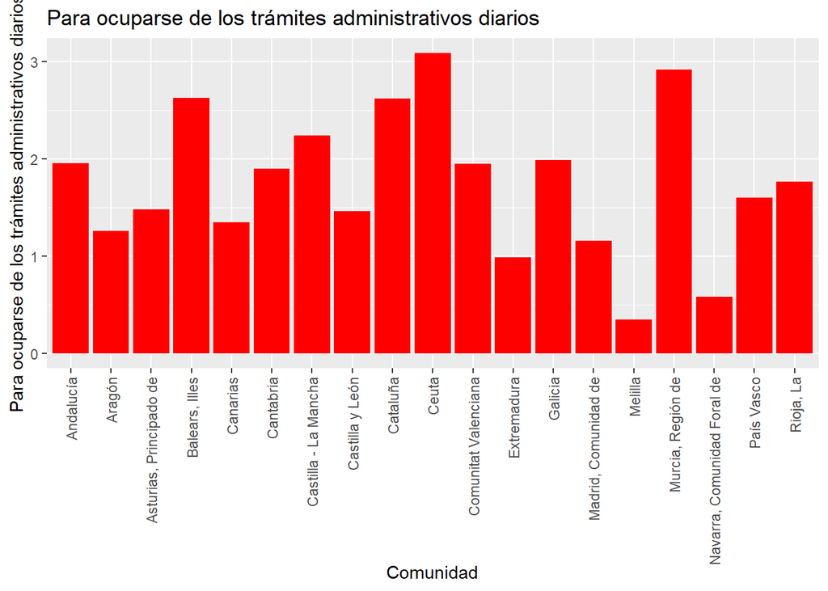

```r
library(tidyverse)
ggplot(data = Limitaciones_vida_cotidiana, aes(x = `Comunidad`, y = `Para ocuparse de los trámites administrativos diarios`)) +  geom_bar(stat="identity", position="stack", fill="red") + ggtitle("Para ocuparse de los trámites administrativos diarios") + theme(axis.text.x = element_text(angle = 90, vjust = 0.5, hjust=1))
```

Con respecto a las limitaciones para ocuparse de los trámites administrativos diarios, Melilla presenta la tasa más baja, mientras que Ceuta presenta valores más altos. No hay ninguna diferencia apreciable a simple vista entre las zonas rurales y las zonas urbanas.

#### Limitaciones en actividades básicas.

**1.** En primer lugar importamos los datos con “read_excel” porque tienen la extensión “.xsls”.

```r
library(readxl)

Limitaciones_actividades_basicas <- read_excel("DATA/Limitaciones actividades basicas.xlsx")

View(Limitaciones_actividades_basicas)
```

**2.** Vamos a comprobar algunas medidas estadísticas con la información recogidos en las distintas columnas

```r
dim(Limitaciones_actividades_basicas)
```

```
## [1] 19  9
```

```r
class(Limitaciones_actividades_basicas)
```

```
## [1] "tbl_df"     "tbl"        "data.frame"
```

El set de datos es un tipo de data frame conocido como **tibble**.

También es conveniente transformar todos los nombres de la columna con “make.names” para cumplan las reglas sintácticas.

```r
make.names(Limitaciones_actividades_basicas)
```

```
## [1] "c..Andalucía....Aragón....Asturias..Principado.de....Balears..Illes....Canarias....Cantabria....Castilla.y.León....Castilla...La.Mancha....Cataluña....Comunitat.Valenciana....Extremadura....Galicia....Madrid..Comunidad.de....Murcia..Región.de....Navarra..Comunidad.Foral.de....País.Vasco....R…
## [2] "c.15.82..14.26..15.93..15.01..16.52..16.31..16.45..17.19..15.61..14.19..13.31..15.49..13.84..19.65..13.82..13.67..16.17..13.81..9.07."
## [3] "c.9.43..9.85..11.34..10.46..8.16..8.08..9.03..8.92..9.95..8.26..7.47..12.64..8.75..10.57..9.95..9.41..9.05..5.65..4.81."
## [4] "c.7.49..5.03..7.59..3.9..5.3..5.62..6.67..6.35..6.68..5.52..4.93..6.58..5.19..6.97..3.33..4.51..6.16..4.74..7.28."
## [5] "c.10.13..8.75..11.48..7.3..10.68..9.7..10.68..10.56..9.53..9.36..8.56..10.84..9.37..9.69..5.79..8.2..8.92..12.19..11.63."
## [6] "c.13.44..10.61..14.38..10.42..11.83..14.4..12.5..12.04..12.12..12.06..9.58..14.85..10.76..14.28..9.97..8.07..8.2..5.08..8.57."
## [7] "c.4.14..2.27..4.69..4.56..3.96..3.93..4.76..3.37..3.94..4.22..3.29..4.4..2.93..6.73..2.13..3.43..5.7..3.33..4.06."
## [8] "c.5.83..5.08..7.04..4.09..6.82..5.67..5.5..7.8..5.99..5.26..4.43..5.6..4.8..7..3.19..5.35..5.24..4.81..10.41."
## [9] "c.5.91..5.51..6.03..2.69..5.7..4.91..6.53..5.38..5.67..6.18..4.6..4.01..5.66..5.11..3.58..3.87..5.27..2.75..6.83."
```

```r
Limitaciones_actividades_basicas$`Para ver`
```

```
##  [1] 15.82 14.26 15.93 15.01 16.52 16.31 16.45 17.19 15.61 14.19 13.31 15.49
## [13] 13.84 19.65 13.82 13.67 16.17 13.81  9.07
```

```r
is.double(Limitaciones_actividades_basicas$`Para ver`)
```

```
## [1] TRUE
```

```r
typeof(Limitaciones_actividades_basicas$`Para ver`)
```

```
## [1] "double"
```

Los datos de todas las columnsa son de tipo “double”.

- **Análisis estadístico general**

```r
summary(Limitaciones_actividades_basicas, na.rm = TRUE)
```

```
##   Comunidad            Para ver        Para oír       Para caminar
##  Length:19          Min.   : 9.07   Min.   : 4.810   Min.   :3.330
##  Class :character   1st Qu.:13.83   1st Qu.: 8.210   1st Qu.:4.980
##  Mode  :character   Median :15.49   Median : 9.050   Median :5.620
##                     Mean   :15.06   Mean   : 9.041   Mean   :5.781
##                     3rd Qu.:16.24   3rd Qu.: 9.950   3rd Qu.:6.675
##                     Max.   :19.65   Max.   :12.640   Max.   :7.590
##  Para subir y bajar escaleras Para recordar o concentrarse Para comunicarse
##  Min.   : 5.790               Min.   : 5.080               Min.   :2.130
##  1st Qu.: 8.835               1st Qu.: 9.775               1st Qu.:3.350
##  Median : 9.690               Median :11.830               Median :3.960
##  Mean   : 9.651               Mean   :11.219               Mean   :3.992
##  3rd Qu.:10.680               3rd Qu.:12.970               3rd Qu.:4.480
##  Max.   :12.190               Max.   :14.850               Max.   :6.730
##  Para levantar objetos Para utilizar manos y dedos
##  Min.   : 3.190        Min.   :2.690
##  1st Qu.: 4.945        1st Qu.:4.305
##  Median : 5.500        Median :5.380
##  Mean   : 5.785        Mean   :5.063
##  3rd Qu.: 6.405        3rd Qu.:5.805
##  Max.   :10.410        Max.   :6.830
```

```r
Media_ver <- mean(Limitaciones_actividades_basicas$`Para ver`, na.rm=TRUE)

Media_ver
```

```
## [1] 15.05895
```

```r
Media_oir <- mean(Limitaciones_actividades_basicas$`Para oír`, na.rm=TRUE)

Media_oir
```

```
## [1] 9.041053
```

```r
Media_caminar <- mean(Limitaciones_actividades_basicas$`Para caminar`, na.rm=TRUE)

Media_caminar
```

```
## [1] 5.781053
```

```r
Media_escaleras <- mean(Limitaciones_actividades_basicas$`Para subir y bajar escaleras`, na.rm=TRUE)

Media_escaleras
```

```
## [1] 9.650526
```

```r
Media_recordar <- mean(Limitaciones_actividades_basicas$`Para recordar o concentrarse`, na.rm=TRUE)

Media_recordar
```

```
## [1] 11.21895
```

```r
Media_comunicarse <- mean(Limitaciones_actividades_basicas$`Para comunicarse`, na.rm=TRUE)

Media_comunicarse
```

```
## [1] 3.991579
```

```r
Media_objetos <- mean(Limitaciones_actividades_basicas$`Para levantar objetos`, na.rm=TRUE)

Media_objetos
```

```
## [1] 5.784737
```

```r
Media_manos <- mean(Limitaciones_actividades_basicas$`Para utilizar manos y dedos`, na.rm=TRUE)

Media_manos
```

```
## [1] 5.062632
```

```r
Medias <- c(Media_ver, Media_oir, Media_caminar, Media_escaleras, Media_recordar, Media_comunicarse, Media_objetos, Media_manos)

max(Medias, na.rm=TRUE)
```

```
## [1] 15.05895
```

Comparando la media de todas las limitaciones relacionadas con actividades básicas vemos que la mayor problemática, en líneas generales, está relacionada con la visión. Es algo sorprendente proque habíamos visto, analizando la naturaleza de la mayor parte de las discapacidades, que las discapacidades relacionadas con la visión no eran muy numerosas. Así consideraremos que la dificultad para ver viene como un problema asociado a una discapacidad que no esté direcatamente originada en los ojos.

Vamos a demostrar que realmente no existe relación entre la dificultad de visión y las discapacidades de la visión.

```r
Mutate_Discapacidad_y_Autonomia_personal <- Discapacidad_y_Autonomia_personal %>%
  select(`Comunidad`, `Tasa de discapacidad de visión`) %>%
  mutate(`Porcentaje tasa discapacidad de visión`= `Tasa de discapacidad de visión`*100)

Mutate_Discapacidad_y_Autonomia_personal <- Mutate_Discapacidad_y_Autonomia_personal %>%
  select(`Comunidad`, `Porcentaje tasa discapacidad de visión`)

Mutate_Discapacidad_y_Autonomia_personal
```

```
## # A tibble: 19 x 2
##    Comunidad                   `Porcentaje tasa discapacidad de visión`
##    <chr>                                                          <dbl>
##  1 Andalucía                                                       1.62
##  2 Aragón                                                          0.55
##  3 Asturias, Principado de                                         0.66
##  4 Balears, Illes                                                  1.37
##  5 Canarias                                                        1.31
##  6 Cantabria                                                       1.03
##  7 Castilla y León                                                 0.94
##  8 Castilla - La Mancha                                            2.08
##  9 Cataluña                                                        1.36
## 10 Comunitat Valenciana                                            1.51
## 11 Extremadura                                                     0.54
## 12 Galicia                                                         0.92
## 13 Madrid, Comunidad de                                            0.91
## 14 Murcia, Región de                                               1.61
## 15 Navarra, Comunidad Foral de                                     1.02
## 16 País Vasco                                                      1.06
## 17 Rioja, La                                                       0.84
## 18 Ceuta                                                           1.51
## 19 Melilla                                                         2.42
```

```r
Select_Limitaciones <- Limitaciones_actividades_basicas %>%
              select(`Comunidad`, `Para ver`)

Select_Limitaciones
```

```
## # A tibble: 19 x 2
##    Comunidad                   `Para ver`
##    <chr>                            <dbl>
##  1 Andalucía                        15.8
##  2 Aragón                           14.3
##  3 Asturias, Principado de          15.9
##  4 Balears, Illes                   15.0
##  5 Canarias                         16.5
##  6 Cantabria                        16.3
##  7 Castilla y León                  16.4
##  8 Castilla - La Mancha             17.2
##  9 Cataluña                         15.6
## 10 Comunitat Valenciana             14.2
## 11 Extremadura                      13.3
## 12 Galicia                          15.5
## 13 Madrid, Comunidad de             13.8
## 14 Murcia, Región de                19.6
## 15 Navarra, Comunidad Foral de      13.8
## 16 País Vasco                       13.7
## 17 Rioja, La                        16.2
## 18 Ceuta                            13.8
## 19 Melilla                           9.07
```

```r
Relacion_vision <- full_join(x = Mutate_Discapacidad_y_Autonomia_personal, y = Select_Limitaciones, by = "Comunidad")

Relacion_vision
```

```
## # A tibble: 19 x 3
##    Comunidad                   `Porcentaje tasa discapacidad de visi~ `Para ver`
##    <chr>                                                        <dbl>      <dbl>
##  1 Andalucía                                                     1.62      15.8
##  2 Aragón                                                        0.55      14.3
##  3 Asturias, Principado de                                       0.66      15.9
##  4 Balears, Illes                                                1.37      15.0
##  5 Canarias                                                      1.31      16.5
##  6 Cantabria                                                     1.03      16.3
##  7 Castilla y León                                               0.94      16.4
##  8 Castilla - La Mancha                                          2.08      17.2
##  9 Cataluña                                                      1.36      15.6
## 10 Comunitat Valenciana                                          1.51      14.2
## 11 Extremadura                                                   0.54      13.3
## 12 Galicia                                                       0.92      15.5
## 13 Madrid, Comunidad de                                          0.91      13.8
## 14 Murcia, Región de                                             1.61      19.6
## 15 Navarra, Comunidad Foral de                                   1.02      13.8
## 16 País Vasco                                                    1.06      13.7
## 17 Rioja, La                                                     0.84      16.2
## 18 Ceuta                                                         1.51      13.8
## 19 Melilla                                                       2.42       9.07
```

```r
summary(Relacion_vision)
```

```
##   Comunidad         Porcentaje tasa discapacidad de visión    Para ver
##  Length:19          Min.   :0.540                          Min.   : 9.07
##  Class :character   1st Qu.:0.915                          1st Qu.:13.83
##  Mode  :character   Median :1.060                          Median :15.49
##                     Mean   :1.224                          Mean   :15.06
##                     3rd Qu.:1.510                          3rd Qu.:16.24
##                     Max.   :2.420                          Max.   :19.65
```

```r
Pivot_vision <- pivot_longer(data = Relacion_vision, names_to = "Variables", values_to = "Valores", cols = c(`Porcentaje tasa discapacidad de visión`:`Para ver`))

Pivot_vision
```

```
## # A tibble: 38 x 3
##    Comunidad               Variables                              Valores
##    <chr>                   <chr>                                    <dbl>
##  1 Andalucía               Porcentaje tasa discapacidad de visión    1.62
##  2 Andalucía               Para ver                                 15.8
##  3 Aragón                  Porcentaje tasa discapacidad de visión    0.55
##  4 Aragón                  Para ver                                 14.3
##  5 Asturias, Principado de Porcentaje tasa discapacidad de visión    0.66
##  6 Asturias, Principado de Para ver                                 15.9
##  7 Balears, Illes          Porcentaje tasa discapacidad de visión    1.37
##  8 Balears, Illes          Para ver                                 15.0
##  9 Canarias                Porcentaje tasa discapacidad de visión    1.31
## 10 Canarias                Para ver                                 16.5
## # ... with 28 more rows
```

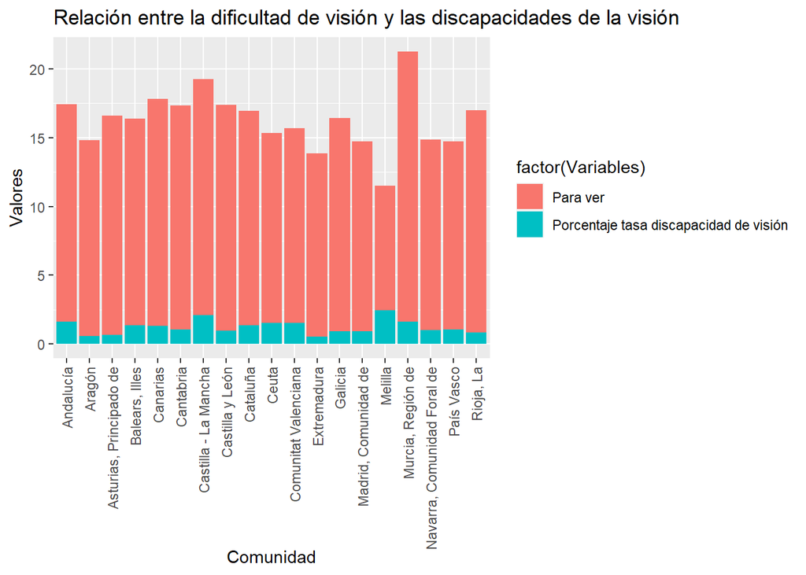

```r
ggplot(data = Pivot_vision, aes(x = `Comunidad`, y = `Valores`)) +  geom_bar(stat="identity", position="stack", aes(fill = factor(Variables))) + ggtitle("Relación entre la dificultad de visión y las discapacidades de la visión") + theme(axis.text.x = element_text(angle = 90, vjust = 0.5, hjust=1))
```

Vemos que no se incrementan de la misma forma ambos atributos, aunque en ciertas comunidades si que parecen crecer de forma proporcional, en la mayoría de ellas no. De hecho, ni el máximo ni el mínimo coinciden.

- **Análisis estadístico por columnas**

```r
summary(Limitaciones_actividades_basicas$`Para ver`, na.rm = TRUE)
```

```
##    Min. 1st Qu.  Median    Mean 3rd Qu.    Max.
##    9.07   13.83   15.49   15.06   16.24   19.65
```

```r
Limitaciones_actividades_basicas$`Comunidad`[Limitaciones_actividades_basicas$`Para ver`== min(Limitaciones_actividades_basicas$`Para ver`, na.rm = TRUE)]
```

```
## [1] "Melilla"
```

```r
Limitaciones_actividades_basicas$`Comunidad`[Limitaciones_actividades_basicas$`Para ver` == max(Limitaciones_actividades_basicas$`Para ver`, na.rm = TRUE)]
```

```
## [1] "Murcia, Región de"
```

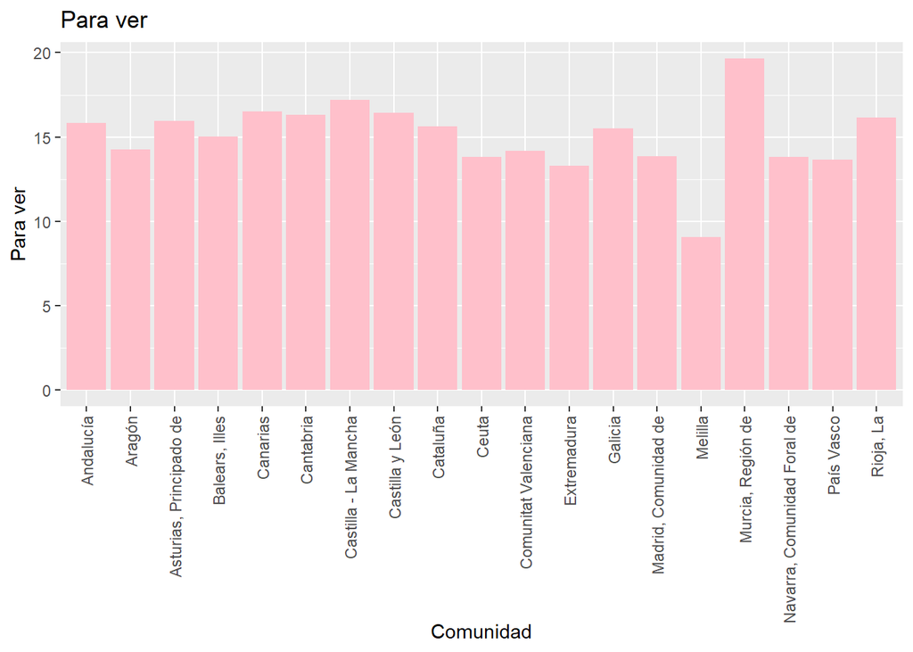

```r
library(tidyverse)
ggplot(data = Limitaciones_actividades_basicas, aes(x = `Comunidad`, y = `Para ver`)) +  geom_bar(stat="identity", position="stack", fill="pink") + ggtitle("Para ver") + theme(axis.text.x = element_text(angle = 90, vjust = 0.5, hjust=1))
```

Con respecto a las limitaciones para ver (las mayoritarias) vemos que en Melilla es donde menos se presentan, mientras que Murcia presenta la mayor proporción.

```r
summary(Limitaciones_actividades_basicas$`Para oír`, na.rm = TRUE)
```

```
##    Min. 1st Qu.  Median    Mean 3rd Qu.    Max.
##   4.810   8.210   9.050   9.041   9.950  12.640
```

```r
Limitaciones_actividades_basicas$`Comunidad`[Limitaciones_actividades_basicas$`Para oír`== min(Limitaciones_actividades_basicas$`Para oír`, na.rm = TRUE)]
```

```
## [1] "Melilla"
```

```r
Limitaciones_actividades_basicas$`Comunidad`[Limitaciones_actividades_basicas$`Para oír` == max(Limitaciones_actividades_basicas$`Para oír`, na.rm = TRUE)]
```

```
## [1] "Galicia"
```

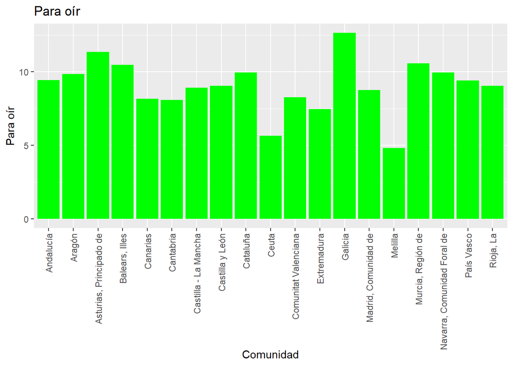

```r
library(tidyverse)
ggplot(data = Limitaciones_actividades_basicas, aes(x = `Comunidad`, y = `Para oír`)) +  geom_bar(stat="identity", position="stack", fill="green") + ggtitle("Para oír") + theme(axis.text.x = element_text(angle = 90, vjust = 0.5, hjust=1))
```

Con respecto a las limitaciones para oír vemos que en Melilla es donde menos se presentan, mientras que Galicia presenta la mayor proporción.

```r
summary(Limitaciones_actividades_basicas$`Para caminar`, na.rm = TRUE)
```

```
##    Min. 1st Qu.  Median    Mean 3rd Qu.    Max.
##   3.330   4.980   5.620   5.781   6.675   7.590
```

```r
Limitaciones_actividades_basicas$`Comunidad`[Limitaciones_actividades_basicas$`Para caminar`== min(Limitaciones_actividades_basicas$`Para caminar`, na.rm = TRUE)]
```

```
## [1] "Navarra, Comunidad Foral de"
```

```r
Limitaciones_actividades_basicas$`Comunidad`[Limitaciones_actividades_basicas$`Para caminar` == max(Limitaciones_actividades_basicas$`Para caminar`, na.rm = TRUE)]
```

```
## [1] "Asturias, Principado de"
```

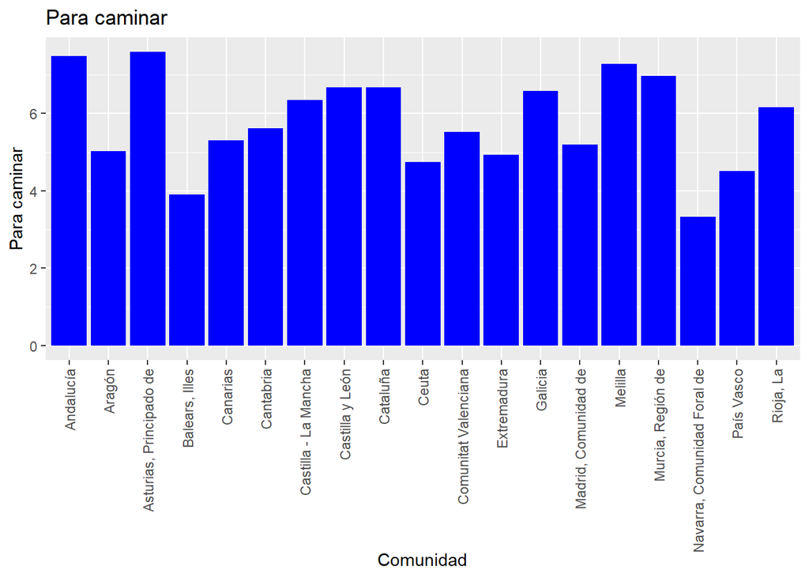

```r
library(tidyverse)
ggplot(data = Limitaciones_actividades_basicas, aes(x = `Comunidad`, y = `Para caminar`)) +  geom_bar(stat="identity", position="stack", fill="blue") + ggtitle("Para caminar") + theme(axis.text.x = element_text(angle = 90, vjust = 0.5, hjust=1))
```

Con respecto a las limitaciones para caminar vemos que en Navarra es donde menos se presentan, mientras que Asturias presenta la mayor proporción.

Considerando que la mayor parte de las tetraplejias que impiden andar vienen causadas por accidentes de tráfico, podemos intuir que en Asturias hay un alto porcentaje de accidentes en la carretera. No es un tema transcendente para nuestro trabajo, pero hemos indagado un poco y, precisamente, hemos descubierto que en Asturias hay muchos accidentes por las carreteras de montaña y la presencia de animales silvestres en la calzada. Por si a alguien le resulta de interés vamos a adjuntar un abstract a continuación que amplia un poco este último tema mencionado.

[Fauna silvestre y accidentes de tráfico en Asturias](https://repositorio.unican.es/xmlui/handle/10902/17202/).

```r
summary(Limitaciones_actividades_basicas$`Para subir y bajar escaleras`, na.rm = TRUE)
```

```
##    Min. 1st Qu.  Median    Mean 3rd Qu.    Max.
##   5.790   8.835   9.690   9.651  10.680  12.190
```

```r
Limitaciones_actividades_basicas$`Comunidad`[Limitaciones_actividades_basicas$`Para subir y bajar escaleras`== min(Limitaciones_actividades_basicas$`Para subir y bajar escaleras`, na.rm = TRUE)]
```

```
## [1] "Navarra, Comunidad Foral de"
```

```r
Limitaciones_actividades_basicas$`Comunidad`[Limitaciones_actividades_basicas$`Para subir y bajar escaleras` == max(Limitaciones_actividades_basicas$`Para subir y bajar escaleras`, na.rm = TRUE)]
```

```
## [1] "Ceuta"
```

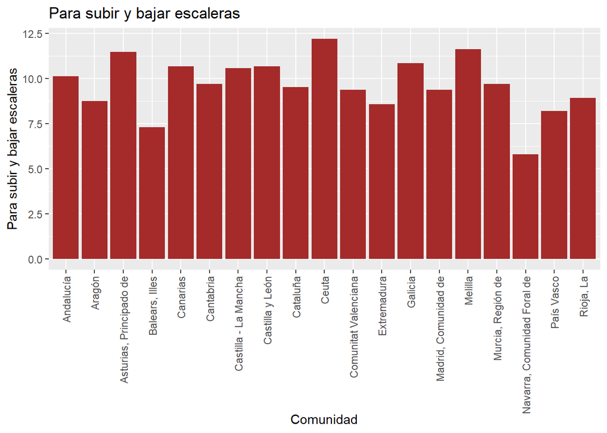

```r
library(tidyverse)
ggplot(data = Limitaciones_actividades_basicas, aes(x = `Comunidad`, y = `Para subir y bajar escaleras`)) +  geom_bar(stat="identity", position="stack", fill="brown") + ggtitle("Para subir y bajar escaleras") + theme(axis.text.x = element_text(angle = 90, vjust = 0.5, hjust=1))
```

Con respecto a las limitaciones para subir y bajar escaleras vemos que en Navarra es donde menos se presentan, mientras que Ceuta presenta la mayor proporción.

```r
summary(Limitaciones_actividades_basicas$`Para recordar o concentrarse`, na.rm = TRUE)
```

```
##    Min. 1st Qu.  Median    Mean 3rd Qu.    Max.
##   5.080   9.775  11.830  11.219  12.970  14.850
```

```r
Limitaciones_actividades_basicas$`Comunidad`[Limitaciones_actividades_basicas$`Para recordar o concentrarse`== min(Limitaciones_actividades_basicas$`Para recordar o concentrarse`, na.rm = TRUE)]
```

```
## [1] "Ceuta"
```

```r
Limitaciones_actividades_basicas$`Comunidad`[Limitaciones_actividades_basicas$`Para recordar o concentrarse` == max(Limitaciones_actividades_basicas$`Para recordar o concentrarse`, na.rm = TRUE)]
```

```
## [1] "Galicia"
```

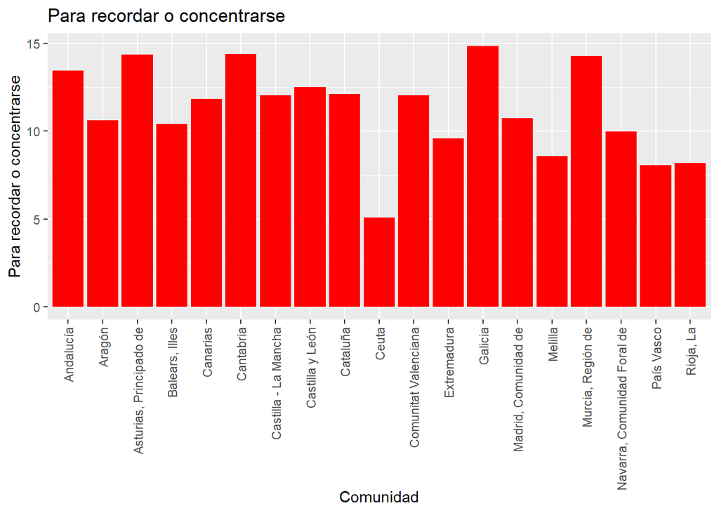

```r
library(tidyverse)
ggplot(data = Limitaciones_actividades_basicas, aes(x = `Comunidad`, y = `Para recordar o concentrarse`)) +  geom_bar(stat="identity", position="stack", fill="red") + ggtitle("Para recordar o concentrarse") + theme(axis.text.x = element_text(angle = 90, vjust = 0.5, hjust=1))
```

Con respecto a las limitaciones para recordar o concentrarse vemos que en Ceuta es donde menos se presentan, mientras que Galicia presenta la mayor proporción.

Este dato es muy importante para los médicos porque una persona que tiene dificultades para recordar o concentrarse tienen algún tipo de afección cognitiva donde se ve involucrado el sistema nervioso. Resulta curioso ver como Galicia presenta el índice más alto tanto de dificultades para oir como para recordar, esto podría ver porque el control de la audición también reside en el cerebro, en concreto, en el lóbulo temporal.

```r
summary(Limitaciones_actividades_basicas$`Para comunicarse`, na.rm = TRUE)
```

```
##    Min. 1st Qu.  Median    Mean 3rd Qu.    Max.
##   2.130   3.350   3.960   3.992   4.480   6.730
```

```r
Limitaciones_actividades_basicas$`Comunidad`[Limitaciones_actividades_basicas$`Para comunicarse`== min(Limitaciones_actividades_basicas$`Para comunicarse`, na.rm = TRUE)]
```

```
## [1] "Navarra, Comunidad Foral de"
```

```r
Limitaciones_actividades_basicas$`Comunidad`[Limitaciones_actividades_basicas$`Para comunicarse` == max(Limitaciones_actividades_basicas$`Para comunicarse`, na.rm = TRUE)]
```

```
## [1] "Murcia, Región de"
```

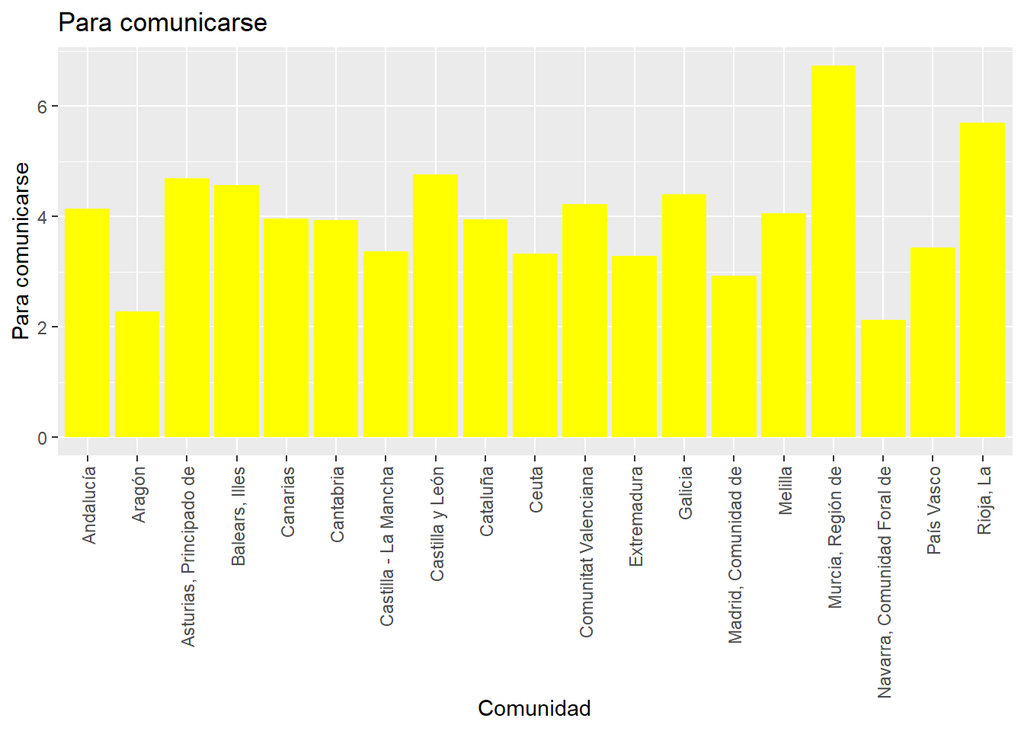

```r
library(tidyverse)
ggplot(data = Limitaciones_actividades_basicas, aes(x = `Comunidad`, y = `Para comunicarse`)) +  geom_bar(stat="identity", position="stack", fill="yellow") + ggtitle("Para comunicarse") + theme(axis.text.x = element_text(angle = 90, vjust = 0.5, hjust=1))
```

Con respecto a las limitaciones para comunicarse vemos que en Navarra es donde menos se presentan, mientras que Murcia presenta la mayor proporción.

```r
summary(Limitaciones_actividades_basicas$`Para levantar objetos`, na.rm = TRUE)
```

```
##    Min. 1st Qu.  Median    Mean 3rd Qu.    Max.
##   3.190   4.945   5.500   5.785   6.405  10.410
```

```r
Limitaciones_actividades_basicas$`Comunidad`[Limitaciones_actividades_basicas$`Para levantar objetos`== min(Limitaciones_actividades_basicas$`Para levantar objetos`, na.rm = TRUE)]
```

```
## [1] "Navarra, Comunidad Foral de"
```

```r
Limitaciones_actividades_basicas$`Comunidad`[Limitaciones_actividades_basicas$`Para levantar objetos` == max(Limitaciones_actividades_basicas$`Para levantar objetos`, na.rm = TRUE)]
```

```
## [1] "Melilla"
```

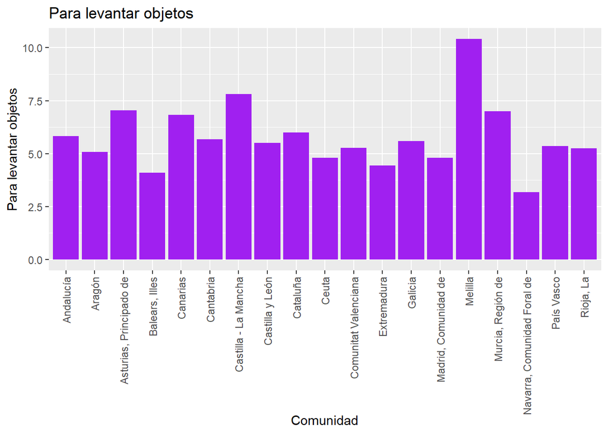

```r
library(tidyverse)
ggplot(data = Limitaciones_actividades_basicas, aes(x = `Comunidad`, y = `Para levantar objetos`)) +  geom_bar(stat="identity", position="stack", fill="purple") + ggtitle("Para levantar objetos") + theme(axis.text.x = element_text(angle = 90, vjust = 0.5, hjust=1))
```

Con respecto a las limitaciones para levantar objetos vemos que en Navarra es donde menos se presentan, mientras que Melilla presenta la mayor proporción.

```r
summary(Limitaciones_actividades_basicas$`Para utilizar manos y dedos`, na.rm = TRUE)
```

```
##    Min. 1st Qu.  Median    Mean 3rd Qu.    Max.
##   2.690   4.305   5.380   5.063   5.805   6.830
```

```r
Limitaciones_actividades_basicas$`Comunidad`[Limitaciones_actividades_basicas$`Para utilizar manos y dedos`== min(Limitaciones_actividades_basicas$`Para utilizar manos y dedos`, na.rm = TRUE)]
```

```
## [1] "Balears, Illes"
```

```r
Limitaciones_actividades_basicas$`Comunidad`[Limitaciones_actividades_basicas$`Para utilizar manos y dedos` == max(Limitaciones_actividades_basicas$`Para utilizar manos y dedos`, na.rm = TRUE)]
```

```
## [1] "Melilla"
```

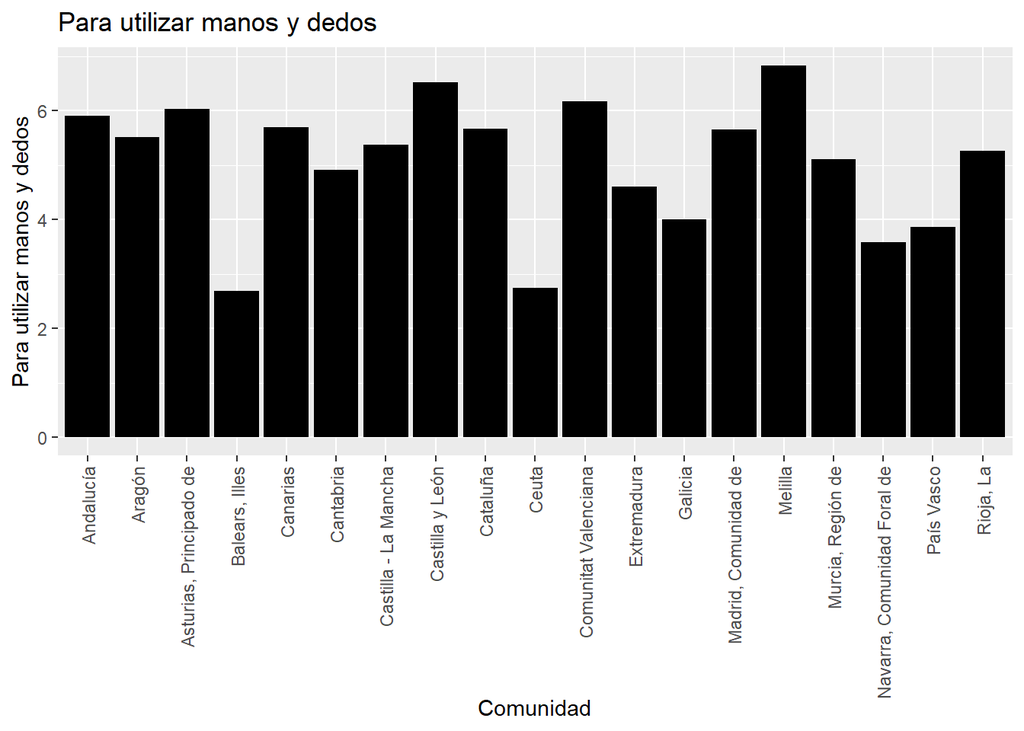

```r
library(tidyverse)
ggplot(data = Limitaciones_actividades_basicas, aes(x = `Comunidad`, y = `Para utilizar manos y dedos`)) +  geom_bar(stat="identity", position="stack", fill="black") + ggtitle("Para utilizar manos y dedos") + theme(axis.text.x = element_text(angle = 90, vjust = 0.5, hjust=1))
```

Con respecto a las limitaciones para utilizar manos y dedos vemos que en Islas Baleares es donde menos se presentan, mientras que Melilla presenta la mayor proporción.

Como la mayor parte de las actividades cotidianas son manuales, es decir, requieren de la utilización de manos y dedos, vamos a ver si existe una relación entre las limitaciones para realizar las tareas del hogar que hemos visto en el anterior set de datos y esta limitación para utilizar manos y dedos.

```r
Select_Limitaciones_cotidianas <- Limitaciones_vida_cotidiana %>%
              select(`Comunidad`, `Para realizar tareas domésticas`)

Select_Limitaciones_cotidianas
```

```
## # A tibble: 19 x 2
##    Comunidad                   `Para realizar tareas domésticas`
##    <chr>                                                   <dbl>
##  1 Andalucía                                                5.91
##  2 Aragón                                                   6.93
##  3 Asturias, Principado de                                  4.96
##  4 Balears, Illes                                           3.01
##  5 Canarias                                                 6.11
##  6 Cantabria                                                5.84
##  7 Castilla y León                                          5.02
##  8 Castilla - La Mancha                                     7.03
##  9 Cataluña                                                 6.17
## 10 Comunitat Valenciana                                     5.83
## 11 Extremadura                                              4.6
## 12 Galicia                                                  7.1
## 13 Madrid, Comunidad de                                     4.66
## 14 Murcia, Región de                                        6.86
## 15 Navarra, Comunidad Foral de                              4.11
## 16 País Vasco                                               5.89
## 17 Rioja, La                                                5.83
## 18 Ceuta                                                    6.38
## 19 Melilla                                                  5.55
```

```r
Select_Limitaciones_basicas <- Limitaciones_actividades_basicas %>%
              select(`Comunidad`, `Para utilizar manos y dedos`)

Select_Limitaciones_basicas
```

```
## # A tibble: 19 x 2
##    Comunidad                   `Para utilizar manos y dedos`
##    <chr>                                               <dbl>
##  1 Andalucía                                            5.91
##  2 Aragón                                               5.51
##  3 Asturias, Principado de                              6.03
##  4 Balears, Illes                                       2.69
##  5 Canarias                                             5.7
##  6 Cantabria                                            4.91
##  7 Castilla y León                                      6.53
##  8 Castilla - La Mancha                                 5.38
##  9 Cataluña                                             5.67
## 10 Comunitat Valenciana                                 6.18
## 11 Extremadura                                          4.6
## 12 Galicia                                              4.01
## 13 Madrid, Comunidad de                                 5.66
## 14 Murcia, Región de                                    5.11
## 15 Navarra, Comunidad Foral de                          3.58
## 16 País Vasco                                           3.87
## 17 Rioja, La                                            5.27
## 18 Ceuta                                                2.75
## 19 Melilla                                              6.83
```

```r
Relacion_manos <- full_join(x = Select_Limitaciones_cotidianas, y = Select_Limitaciones_basicas, by = "Comunidad")

Relacion_manos
```

```
## # A tibble: 19 x 3
##    Comunidad                   `Para realizar tareas dom~ `Para utilizar manos ~
##    <chr>                                            <dbl>                  <dbl>
##  1 Andalucía                                         5.91                   5.91
##  2 Aragón                                            6.93                   5.51
##  3 Asturias, Principado de                           4.96                   6.03
##  4 Balears, Illes                                    3.01                   2.69
##  5 Canarias                                          6.11                   5.7
##  6 Cantabria                                         5.84                   4.91
##  7 Castilla y León                                   5.02                   6.53
##  8 Castilla - La Mancha                              7.03                   5.38
##  9 Cataluña                                          6.17                   5.67
## 10 Comunitat Valenciana                              5.83                   6.18
## 11 Extremadura                                       4.6                    4.6
## 12 Galicia                                           7.1                    4.01
## 13 Madrid, Comunidad de                              4.66                   5.66
## 14 Murcia, Región de                                 6.86                   5.11
## 15 Navarra, Comunidad Foral de                       4.11                   3.58
## 16 País Vasco                                        5.89                   3.87
## 17 Rioja, La                                         5.83                   5.27
## 18 Ceuta                                             6.38                   2.75
## 19 Melilla                                           5.55                   6.83
```

```r
Pivot_manos <- pivot_longer(data = Relacion_manos, names_to = "Variables", values_to = "Valores", cols = c(`Para realizar tareas domésticas`:`Para utilizar manos y dedos`))

Pivot_manos
```

```
## # A tibble: 38 x 3
##    Comunidad               Variables                       Valores
##    <chr>                   <chr>                             <dbl>
##  1 Andalucía               Para realizar tareas domésticas    5.91
##  2 Andalucía               Para utilizar manos y dedos        5.91
##  3 Aragón                  Para realizar tareas domésticas    6.93
##  4 Aragón                  Para utilizar manos y dedos        5.51
##  5 Asturias, Principado de Para realizar tareas domésticas    4.96
##  6 Asturias, Principado de Para utilizar manos y dedos        6.03
##  7 Balears, Illes          Para realizar tareas domésticas    3.01
##  8 Balears, Illes          Para utilizar manos y dedos        2.69
##  9 Canarias                Para realizar tareas domésticas    6.11
## 10 Canarias                Para utilizar manos y dedos        5.7
## # ... with 28 more rows
```

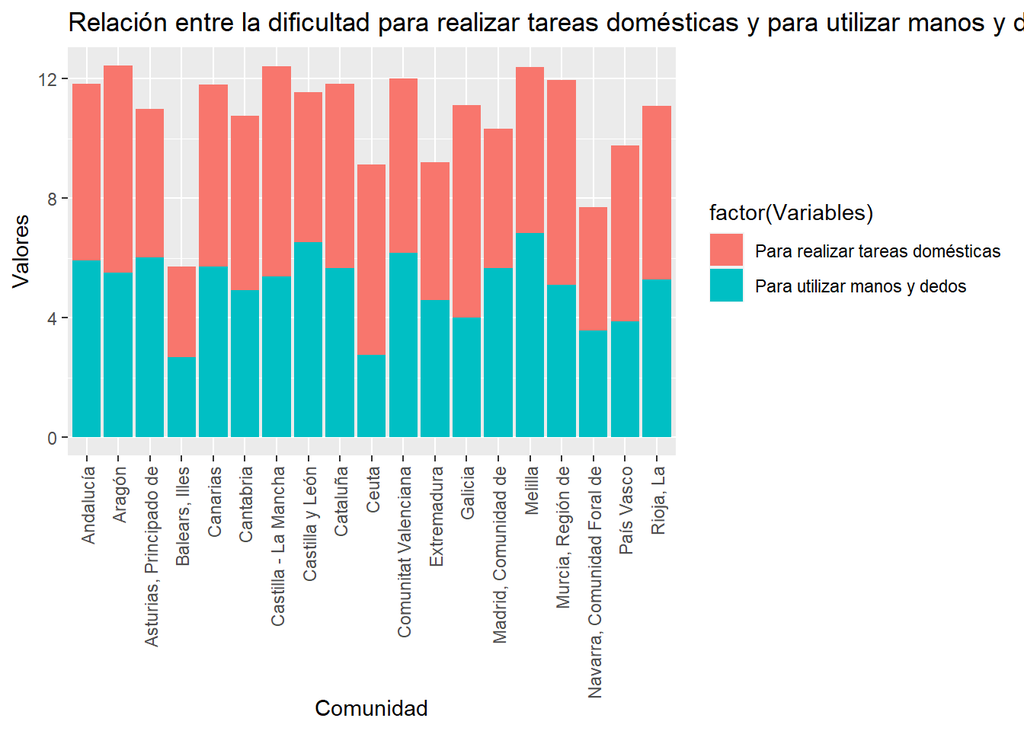

```r
ggplot(data = Pivot_manos, aes(x = `Comunidad`, y = `Valores`)) +  geom_bar(stat="identity", position="stack", aes(fill = factor(Variables))) + ggtitle("Relación entre la dificultad para realizar tareas domésticas y para utilizar manos y dedos") + theme(axis.text.x = element_text(angle = 90, vjust = 0.5, hjust=1))
```

- **Conclusiones sobre las limitaciones en actividades básicas**

En principio no vemos ningun cambio significativos entre las limitaciones que presentan los discapacitados que viven en zonas rurales y los que viven en zonas urbanas. Aunque podemos cuestionarnos en qué zonas recibirán más ayudas los discapacitados para lidiar con todas estas limitaciones, lo intetaremos contestar más adelante.

Aún así es cierto que nos resulta interesante el caso de dos comunidades. Primeramente, Navarra vuelve a repetirse numerosas veces como la comundiades con menor índice de limitaciones, esto refleja, nuevamente, la gran calidad de su sistema sanitario. Y, por otro lado, la Región de Murcia ha aparecido en varias ocasiones como la comunidad con mayor proporción de discapacitados con limitaciones, este hecho nos hace dudar sobre la calidad de su asistencia sanitaria.

#### Cuidadores

**1.** En primer lugar importamos los datos con “read_excel” porque tienen la extensión “.xsls”.

```r
library(readxl)

Cuidadores <- read_excel("DATA/Cuidadores.xlsx")

View(Cuidadores)
```

**2.** Vamos a comprobar algunas medidas estadísticas de las diferentes columnas del set, que en este caso son tres.

```r
dim(Cuidadores)
```

```
## [1] 20  4
```

```r
class(Cuidadores)
```

```
## [1] "tbl_df"     "tbl"        "data.frame"
```

El set de datos es un tipo de data frame conocido como **tibble**.

También es conveniente que todos los nombres de las columnas cumplan las reglas sintácticas. En este caso todos los datos dedichas columnas son de tipo “double”.

- **Análisis estadístico general**

```r
summary(Cuidadores, na.rm = TRUE)
```

```
##   Comunidad         En el hogar de la persona que cuida En otro hogar
##  Length:20          Min.   :   2.50                     Min.   :  0.500
##  Class :character   1st Qu.:  21.88                     1st Qu.:  4.725
##  Mode  :character   Median :  44.05                     Median : 11.650
##                     Mean   : 128.01                     Mean   : 34.285
##                     3rd Qu.: 110.42                     3rd Qu.: 25.450
##                     Max.   :1280.20                     Max.   :343.000
##    No consta
##  Min.   :  0.000
##  1st Qu.:  4.975
##  Median : 15.250
##  Mean   : 46.485
##  3rd Qu.: 29.150
##  Max.   :464.900
```

- **Análisis estadístico por columna**

```r
summary(Cuidadores$`En el hogar de la persona que cuida`, na.rm = TRUE)
```

```
##    Min. 1st Qu.  Median    Mean 3rd Qu.    Max.
##    2.50   21.88   44.05  128.01  110.42 1280.20
```

```r
Cuidadores$`Comunidad`[Cuidadores$`En el hogar de la persona que cuida` == min(Cuidadores$`En el hogar de la persona que cuida`, na.rm = TRUE)]
```

```
## [1] "Melilla"
```

```r
Cuidadores$`Comunidad`[Cuidadores$`En el hogar de la persona que cuida` == max(Cuidadores$`En el hogar de la persona que cuida`, na.rm = TRUE)]
```

```
## [1] "Andalucía"
```

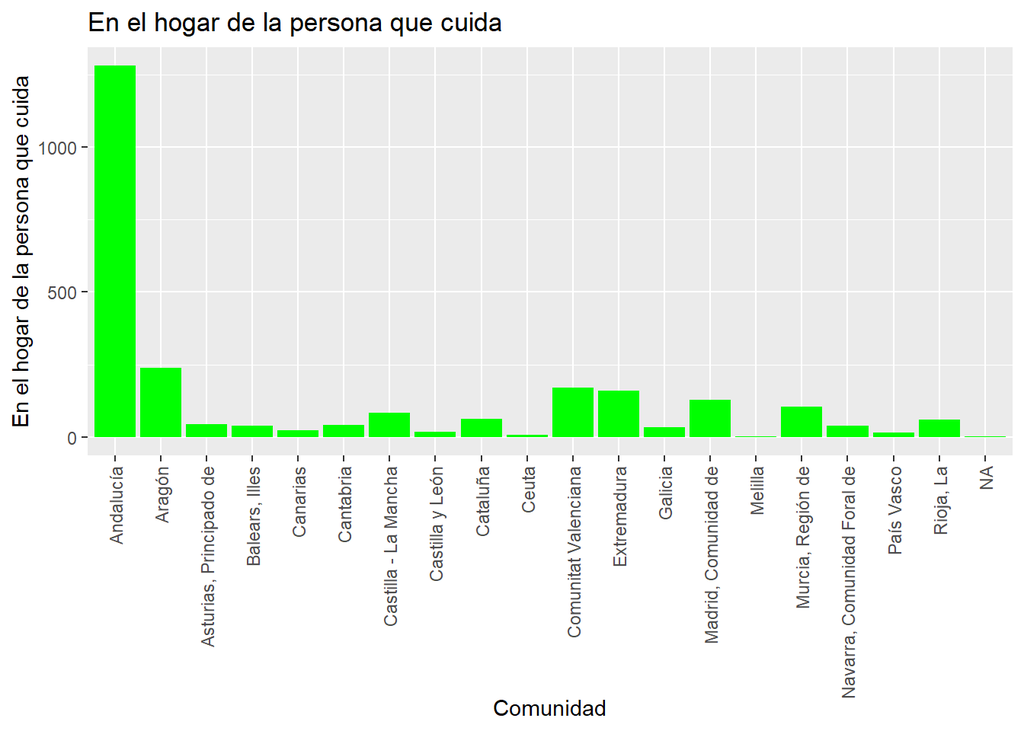

```r
library(tidyverse)
ggplot(data = Cuidadores, aes(x = `Comunidad`, y = `En el hogar de la persona que cuida`)) +  geom_bar(stat="identity", position="stack", fill="green") + ggtitle("En el hogar de la persona que cuida") + theme(axis.text.x = element_text(angle = 90, vjust = 0.5, hjust=1))
```

```r
summary(Cuidadores$`En otro hogar`, na.rm = TRUE)
```

```
##    Min. 1st Qu.  Median    Mean 3rd Qu.    Max.
##   0.500   4.725  11.650  34.285  25.450 343.000
```

```r
Cuidadores$`Comunidad`[Cuidadores$`En otro hogar` == min(Cuidadores$`En otro hogar`, na.rm = TRUE)]
```

```
## [1] NA
```

```r
Cuidadores$`Comunidad`[Cuidadores$`En otro hogar` == max(Cuidadores$`En otro hogar`, na.rm = TRUE)]
```

```
## [1] "Andalucía"
```

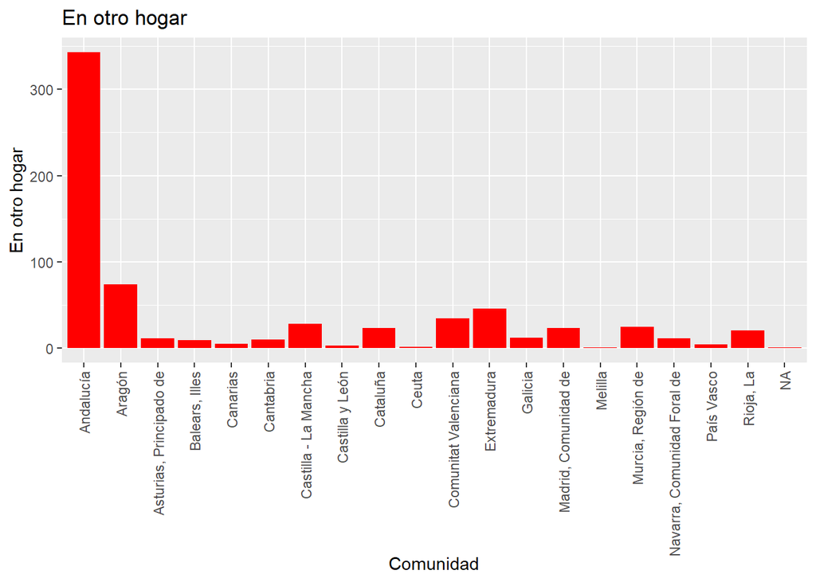

```r
library(tidyverse)
ggplot(data = Cuidadores, aes(x = `Comunidad`, y = `En otro hogar`)) +  geom_bar(stat="identity", position="stack", fill="red") + ggtitle("En otro hogar") + theme(axis.text.x = element_text(angle = 90, vjust = 0.5, hjust=1))
```

```r
summary(Cuidadores$`No consta`, na.rm = TRUE)
```

```
##    Min. 1st Qu.  Median    Mean 3rd Qu.    Max.
##   0.000   4.975  15.250  46.485  29.150 464.900
```

```r
Cuidadores$`Comunidad`[Cuidadores$`No consta` == min(Cuidadores$`No consta`, na.rm = TRUE)]
```

```
## [1] NA
```

```r
Cuidadores$`Comunidad`[Cuidadores$`No consta` == max(Cuidadores$`No consta`, na.rm = TRUE)]
```

```
## [1] "Andalucía"
```

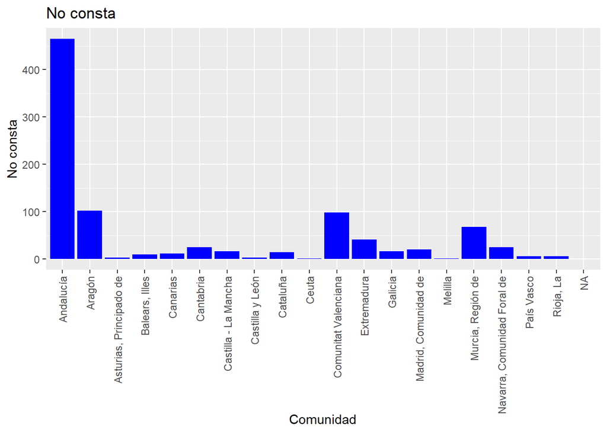

```r
library(tidyverse)
ggplot(data = Cuidadores, aes(x = `Comunidad`, y = `No consta`)) +  geom_bar(stat="identity", position="stack", fill="blue")+ ggtitle("No consta") + theme(axis.text.x = element_text(angle = 90, vjust = 0.5, hjust=1))
```

- **Conclusiones sobre los Cuidadores de las personas con discapacidad**

Como hemos análizado tres tipos de cuidadores, mediante la comparación de las medias podemos determinar que hay más discapacitados viven en el hogar de la persona que los cuida que los que viven en otros hogares, siempre teniendo encuenta el posible margen de error que podrían causar los que no constan. Cabe a destacar el caso de Andalucía, por sus valores tan significativos y dispares al resto de las comunidades. En las conclusiones finales haremos un join para relacionar el set de los cuidadores junto con el de la economia y el de ayudas, ya que creemos que la relación entre los tres factores puede ser interesante en nuetra investigación.

Aquí vamos a incluir una noticia de una situación sobre un discapacitado en Andalucia donde el sistema sanitario no reconoce su grado de discapacidad. Creemos que si realmente hay muchos casos como este, esto podría una causa por la que una gran cantidad de discapacitados tienen que vivir en la casa de sus cuidadores ante una falta de atención médica.

- [Caso Andalucia](https://www.eldiario.es/andalucia/anos-espera-reconocimiento-discapacidad-andalucia_1_8461860.htmll/)

#### Análisis de necesidades no satifechas de cuidados médicos.

**1.** En primer lugar importamos los datos con “read_excel” porque tienen la extensión “.xsls”.

```r
library(readxl)
Necesidades_no_satisfechas <- read_excel("DATA/Necesidades_no _satisfechas.xlsx")
View(Necesidades_no_satisfechas)
```

```r
dim(Necesidades_no_satisfechas)
```

```
## [1] 19  2
```

```r
class(Necesidades_no_satisfechas)
```

```
## [1] "tbl_df"     "tbl"        "data.frame"
```

El set de datos es un tipo de data frame conocido como **tibble**.

Además sabemos que el tibble contiene **19 filas y 2 columnas**, esto es así porque España se compone de 17 comunidades autónomas y 2 cuidades autónomas.

También es conveniente transformar todos los nombres de la columna con “make.names” para cumplan las reglas sintácticas.

```r
make.names(Necesidades_no_satisfechas)
```

```
## [1] "c..Andalucía....Aragón....Asturias..Principado.de....Balears..Illes....Canarias....Cantabria....Castilla.y.León....Castilla...La.Mancha....Cataluña....Comunitat.Valenciana....Extremadura....Galicia....Madrid..Comunidad.de....Murcia..Región.de....Navarra..Comunidad.Foral.de....País.Vasco....R…
## [2] "c.0.5..0..0.2..0.6..1.4..0..0.3..0.5..0.3..0.8..0.1..0..0.4..0.2..0.9..0.1..0.1..0..0."
```

```r
Necesidades_no_satisfechas$Necesidades
```

```
##  [1] 0.5 0.0 0.2 0.6 1.4 0.0 0.3 0.5 0.3 0.8 0.1 0.0 0.4 0.2 0.9 0.1 0.1 0.0 0.0
```

```r
is.double(Necesidades_no_satisfechas$Necesidades)
```

```
## [1] TRUE
```

```r
typeof(Necesidades_no_satisfechas$Necesidades)
```

```
## [1] "double"
```

Los datos de la columna “Necesidades” son de tipo “double”.

- **La media y la mediana**

```r
mean(as.double(Necesidades_no_satisfechas$Necesidades), na.rm = TRUE)
```

```
## [1] 0.3368421
```

- **Mínimo y máximo**

```r
Necesidades_no_satisfechas$`Comunidades`[Necesidades_no_satisfechas$Necesidades == min(as.double(Necesidades_no_satisfechas$Necesidades), na.rm = TRUE)]
```

```
## [1] "Aragón"    "Cantabria" "Galicia"   "Ceuta"     "Melilla"
```

Las comunidades autónomas españolas con mayor satisfacion, es decir, menor necesidades NO satisfechas son **Aragón** , **Cantabria**, **Galicia** y las ciudades autónomas, **Ceuta** y **Melilla** con 0.

```r
Necesidades_no_satisfechas$`Comunidades`[Necesidades_no_satisfechas$Necesidades == max(as.double(Necesidades_no_satisfechas$Necesidades), na.rm = TRUE)]
```

```
## [1] "Canarias"
```

La comunidad autónoma menos satisfecha es **Canarias**, con 1.4.

- **Cálculo conjunto de varias medidas estadísticas (summary)**

```r
summary(as.double(Necesidades_no_satisfechas$Necesidades), na.rm = TRUE)
```

```
##    Min. 1st Qu.  Median    Mean 3rd Qu.    Max.
##  0.0000  0.0500  0.2000  0.3368  0.5000  1.4000
```

El mínimo es: 0

El máximo es: 1.4

El primer cuartil es: 0.05

El tercer cuartil es: 0.5

- **Análisis de las comunidades más significativas**
  - **Castilla y León**: zona rural

```r
 Necesidades_no_satisfechas$`Necesidades`[Necesidades_no_satisfechas$`Comunidades` == "Castilla y León"]
```

```
## [1] 0.3
```

[output not shown]

- **Aragón**: zona rural

```r
Necesidades_no_satisfechas$`Necesidades`[Necesidades_no_satisfechas$`Comunidades` == "Aragón"]
```

```
## [1] 0
```

```
Los habitantes de Aragón están completamente satisfechos con su sistema sanitario su índice de necesidades no satisfechas es nulo.
```

- **Murcia**: zona urbana

```r
Necesidades_no_satisfechas$`Necesidades`[Necesidades_no_satisfechas$`Comunidades` == "Murcia, Región de"]
```

```
## [1] 0.2
```

[output not shown]

- **Madrid**: zona urbana

```r
Necesidades_no_satisfechas$`Necesidades`[Necesidades_no_satisfechas$`Comunidades` == "Madrid, Comunidad de"]
```

```
## [1] 0.4
```

```
La necesidades mecicas no satisfechas en Madrid son ligeramente más altas, 0.4.
```

- **Representación gráfica de la información demográfica**

Antes de comenzar a graficar hay que tener instalado el paquete básico *Tidyverse*.

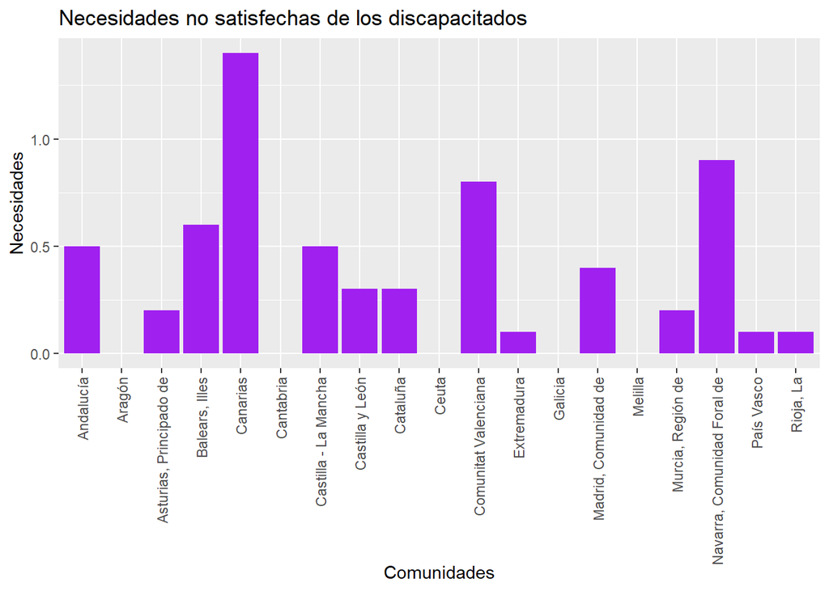

```r
library(tidyverse)

ggplot(data = Necesidades_no_satisfechas, aes(x = `Comunidades`, y = `Necesidades`)) +  geom_bar(stat="identity", position="stack", fill="purple") + ggtitle("Necesidades no satisfechas") + ggtitle("Necesidades no satisfechas de los discapacitados") + theme(axis.text.x = element_text(angle = 90, vjust = 0.5, hjust=1))
```

- **Conclusiones sobre las necesidades no satisfechas de cuidados médicos**

La comunidad menos satisfecha con sus necesidades de cuidados médicos es Canarias la razón podría deberse a que al ser unas islas bastante alejadas de la Península pueden tener menos especialistas y facilidades en sus necesidades médicas.

Las comunidades autónomas españolas con mayor satisfacion, es decir, menor necesidades NO satisfechas son Aragón, Cantabria, Galicia y las ciudades autónomas, Ceuta y Melilla.

Como hemos analizado anteriormente Murcia y Madrid son las comunidades con mayor población, ambas tienen una baja puntuación por lo que sus necesidades de cuidados médicos son aceptables. Podemos relacionar esto con que a un mayor índice de población mayor numero de centros de salud y recursos para tratar a los pacientes y/o cuidadores.

Es probable que las necesidades no satisfechas de cuidados médicos estén marcadas por otros factores como el nivel económico de la comunidad, la media de edad de sus habitantes, etc.

#### Barreras en la participación social

**1.** En primer lugar importamos los datos con “read_excel” porque tienen la extensión “.xsls”.

```r
library(readxl)
Barreras_en_la_participación_social <- read_excel("DATA/Barreras en la participación social.xlsx")
View(Barreras_en_la_participación_social)
```

**2.** Vamos a comprobar algunas medidas estadísticas con la información recogidos en las distintas columnas

```r
dim(Barreras_en_la_participación_social)
```

```
## [1] 19 11
```

```r
class(Barreras_en_la_participación_social)
```

```
## [1] "tbl_df"     "tbl"        "data.frame"
```

El set de datos es un tipo de data frame conocido como **tibble**.

Además sabemos que el tibble contiene **19 filas y 11 columnas**, esto es así porque España se compone de 17 comunidades autónomas y 2 cuidades autónomas.

También es conveniente que todos los nombres de las columnas cumplan las reglas sintácticas. En este caso todos los datos de dichas columnas son de tipo “double”.

- **Análisis estadístico general**

```r
summary(Barreras_en_la_participación_social, na.rm = TRUE)
```

```
##   Comunidad         Salir de casa   Uso del transporte
##  Length:19          Min.   :37.17   Min.   :23.80
##  Class :character   1st Qu.:40.98   1st Qu.:27.79
##  Mode  :character   Median :44.66   Median :33.19
##                     Mean   :45.83   Mean   :32.46
##                     3rd Qu.:51.59   3rd Qu.:36.50
##                     Max.   :56.36   Max.   :44.65
##  Acceso y movilidad por los edificios Actividades formativas
##  Min.   :23.58                        Min.   :32.34
##  1st Qu.:28.89                        1st Qu.:36.52
##  Median :32.05                        Median :41.28
##  Mean   :31.15                        Mean   :41.23
##  3rd Qu.:33.84                        3rd Qu.:45.47
##  Max.   :35.83                        Max.   :51.64
##  Acceso a un empleo adecuado Uso de internet Contacto y apoyo social
##  Min.   :48.61               Min.   :20.17   Min.   :1.440
##  1st Qu.:52.27               1st Qu.:21.88   1st Qu.:3.670
##  Median :56.20               Median :24.81   Median :4.270
##  Mean   :56.97               Mean   :24.89   Mean   :4.423
##  3rd Qu.:59.67               3rd Qu.:27.87   3rd Qu.:5.600
##  Max.   :70.11               Max.   :31.14   Max.   :7.210
##  Actividades de ocio y culturales Situación económica Discriminación
##  Min.   :62.40                    Min.   :26.40       Min.   : 9.19
##  1st Qu.:67.77                    1st Qu.:36.65       1st Qu.:10.48
##  Median :70.97                    Median :41.46       Median :12.23
##  Mean   :71.18                    Mean   :40.16       Mean   :12.36
##  3rd Qu.:75.08                    3rd Qu.:43.31       3rd Qu.:14.01
##  Max.   :78.70                    Max.   :52.92       Max.   :16.64
```

```r
Media_SalirDeCasa <- mean(as.double(Barreras_en_la_participación_social$`Salir de casa`), na.rm=TRUE)

Media_UsoTransporte <- mean(as.double(Barreras_en_la_participación_social$`Uso del transporte`), na.rm=TRUE)

Media_AccesoEdificios <- mean(as.double(Barreras_en_la_participación_social$` Acceso y movilidad por los edificios `), na.rm=TRUE)
Media_ActFormativas <- mean(as.double(Barreras_en_la_participación_social$`Actividades formativas`), na.rm=TRUE)

Media_Empleo <- mean(as.double(Barreras_en_la_participación_social$`Acceso a un empleo adecuado`), na.rm=TRUE)

Media_UsoInternet <- mean(as.double(Barreras_en_la_participación_social$`Uso de internet`), na.rm=TRUE)

Media_ApoyoSocial <- mean(as.double(Barreras_en_la_participación_social$` Contacto y apoyo social `), na.rm=TRUE)
Media_Ocio <- mean(as.double(Barreras_en_la_participación_social$`Actividades de ocio y culturales`), na.rm=TRUE)

Media_SitEconomica <- mean(as.double(Barreras_en_la_participación_social$`Situación económica`), na.rm=TRUE)

Media_Discriminacion <- mean(as.double(Barreras_en_la_participación_social$`Discriminación`), na.rm=TRUE)

Medias <- c(Media_SalirDeCasa, Media_UsoTransporte, Media_AccesoEdificios, Media_ActFormativas, Media_Empleo, Media_UsoInternet, Media_ApoyoSocial, Media_Ocio, Media_SitEconomica, Media_Discriminacion)

max(Medias, na.rm=TRUE)
```

```
## [1] 71.18316
```

- **Análisis estadístico por columnas**

```r
summary(Barreras_en_la_participación_social $` Salir de casa`, na.rm = TRUE)
```

```
## Length  Class   Mode
##      0   NULL   NULL
```

```r
Barreras_en_la_participación_social$`Comunidad`[as.double(Barreras_en_la_participación_social $`Salir de casa`)== min(as.double(Barreras_en_la_participación_social $`Salir de casa`), na.rm = TRUE)]
```

```
## [1] "Castilla y León"
```

```r
Barreras_en_la_participación_social$`Comunidad`[as.double (Barreras_en_la_participación_social$`Salir de casa`) == max(as.double(Barreras_en_la_participación_social $`Salir de casa`), na.rm = TRUE)]
```

```
## [1] "Andalucía"
```

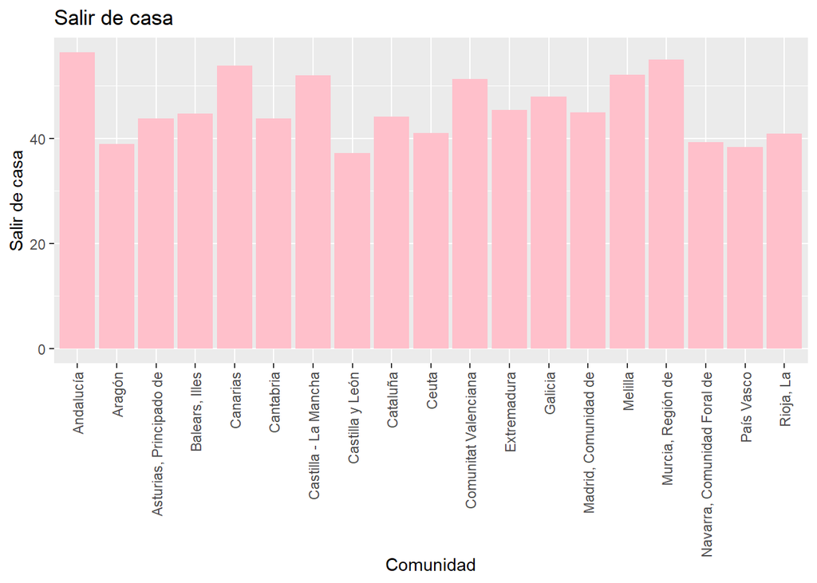

```r
library(tidyverse)
ggplot(data = Barreras_en_la_participación_social, aes(x = `Comunidad`, y = `Salir de casa`)) +  geom_bar(stat="identity", position="stack", fill="pink") + ggtitle("Salir de casa") + theme(axis.text.x = element_text(angle = 90, vjust = 0.5, hjust=1))
```

Con respecto a la barrera social de salir de casa Castilla y leon presenta el índice más bajo, mientras que Andalucía es la que tiene mayor proporción. Esto podría deberse al clima, ya que en Andalucía el calor constante que hace durantes la mayoria de los meses, podría incomodar el salir de casa. Y por lo contraría como el clima de Castilla y Leon es más cambiante y varia más la temperatura sería más agradable en este caso.

```r
summary(Barreras_en_la_participación_social $`Uso del transporte`, na.rm = TRUE)
```

```
##    Min. 1st Qu.  Median    Mean 3rd Qu.    Max.
##   23.80   27.79   33.19   32.46   36.50   44.65
```

```r
Barreras_en_la_participación_social$`Comunidad`[as.double(Barreras_en_la_participación_social $`Uso del transporte`)== min(as.double(Barreras_en_la_participación_social $`Uso del transporte`), na.rm = TRUE)]
```

```
## [1] "País Vasco" "Ceuta"
```

```r
Barreras_en_la_participación_social$`Comunidad`[as.double(Barreras_en_la_participación_social$`Uso del transporte`) == max(as.double(Barreras_en_la_participación_social$`Uso del transporte`), na.rm = TRUE)]
```

```
## [1] "Murcia, Región de"
```

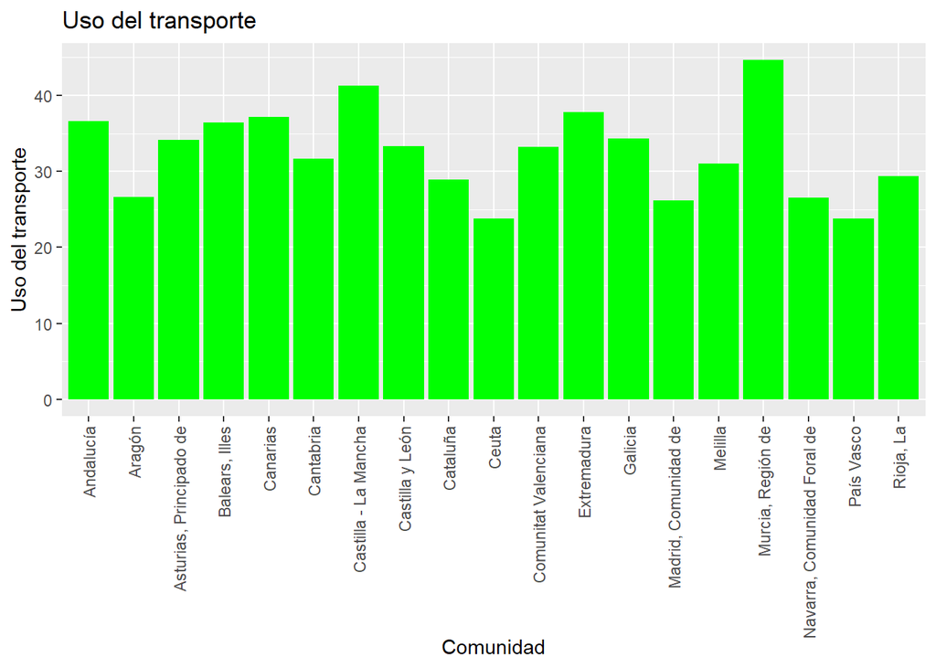

```r
library(tidyverse)
ggplot(data = Barreras_en_la_participación_social, aes(x = `Comunidad`, y = `Uso del transporte`)) +  geom_bar(stat="identity", position="stack", fill="green") + ggtitle("Uso del transporte") + theme(axis.text.x = element_text(angle = 90, vjust = 0.5, hjust=1))
```

```r
summary(Barreras_en_la_participación_social $`Acceso y movilidad por los edificios`, na.rm = TRUE)
```

```
##    Min. 1st Qu.  Median    Mean 3rd Qu.    Max.
##   23.58   28.89   32.05   31.15   33.84   35.83
```

```r
Barreras_en_la_participación_social$`Comunidad`[as.double(Barreras_en_la_participación_social $`Acceso y movilidad por los edificios`)== min(as.double(Barreras_en_la_participación_social $`Acceso y movilidad por los edificios`), na.rm = TRUE)]
```

```
## [1] "Navarra, Comunidad Foral de"
```

```r
Barreras_en_la_participación_social$`Comunidad`[as.double(Barreras_en_la_participación_social $`Acceso y movilidad por los edificios`) == max(as.double(Barreras_en_la_participación_social $`Acceso y movilidad por los edificios`), na.rm = TRUE)]
```

```
## [1] "Canarias"
```

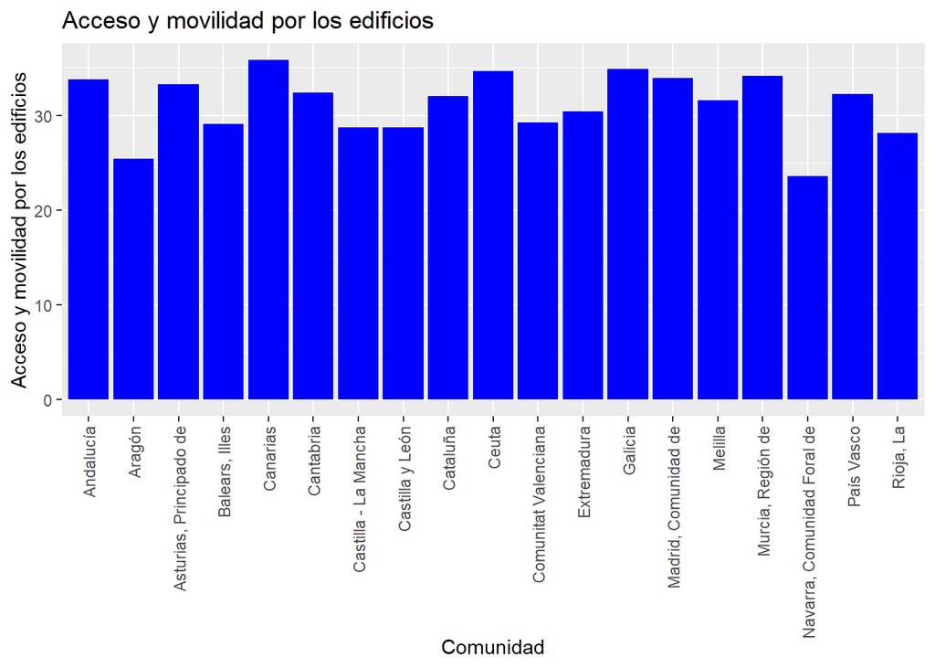

```r
library(tidyverse)
ggplot(data = Barreras_en_la_participación_social, aes(x = `Comunidad`, y = `Acceso y movilidad por los edificios`)) +  geom_bar(stat="identity", position="stack", fill="blue") + ggtitle("Acceso y movilidad por los edificios") + theme(axis.text.x = element_text(angle = 90, vjust = 0.5, hjust=1))
```

```r
summary(Barreras_en_la_participación_social $`Actividades formativas`, na.rm = TRUE)
```

```
##    Min. 1st Qu.  Median    Mean 3rd Qu.    Max.
##   32.34   36.52   41.28   41.23   45.47   51.64
```

```r
Barreras_en_la_participación_social$`Comunidad`[as.double(Barreras_en_la_participación_social $`Actividades formativas`)== min(as.double(Barreras_en_la_participación_social $`Actividades formativas`), na.rm = TRUE)]
```

```
## [1] "Navarra, Comunidad Foral de"
```

```r
Barreras_en_la_participación_social$`Comunidad`[as.double(Barreras_en_la_participación_social $`Actividades formativas`) == max(as.double(Barreras_en_la_participación_social $`Actividades formativas`), na.rm = TRUE)]
```

```
## [1] "Canarias"
```

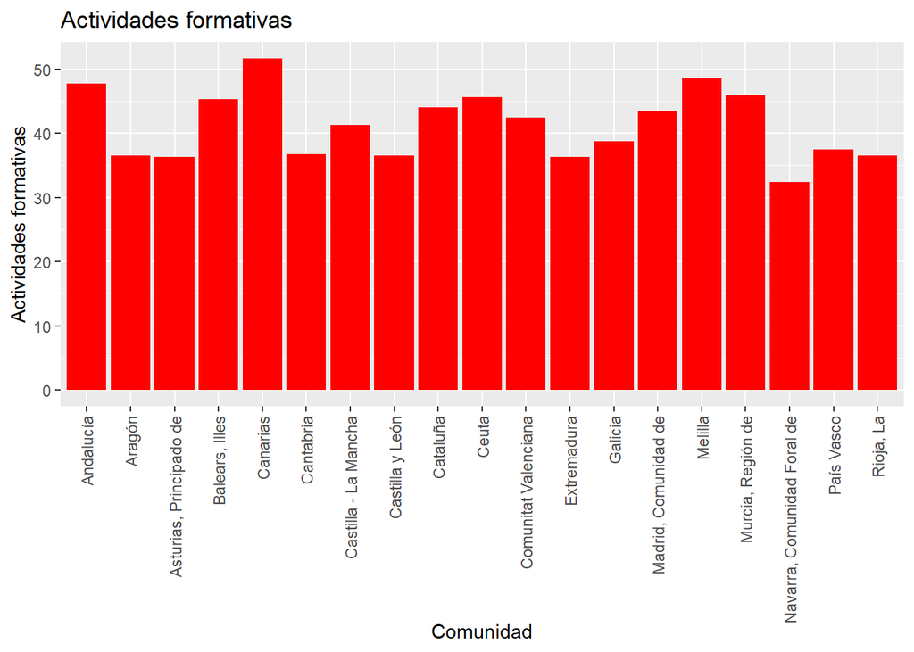

```r
library(tidyverse)
ggplot(data = Barreras_en_la_participación_social, aes(x = `Comunidad`, y = `Actividades formativas`)) +  geom_bar(stat="identity", position="stack", fill="red") + ggtitle("Actividades formativas") + theme(axis.text.x = element_text(angle = 90, vjust = 0.5, hjust=1))
```

```r
summary(Barreras_en_la_participación_social $`Acceso a un empleo adecuado`, na.rm = TRUE)
```

```
##    Min. 1st Qu.  Median    Mean 3rd Qu.    Max.
##   48.61   52.27   56.20   56.97   59.67   70.11
```

```r
Barreras_en_la_participación_social$`Comunidad`[as.double(Barreras_en_la_participación_social $`Acceso a un empleo adecuado`)== min(as.double(Barreras_en_la_participación_social $`Acceso a un empleo adecuado`), na.rm = TRUE)]
```

```
## [1] "Navarra, Comunidad Foral de"
```

```r
Barreras_en_la_participación_social$`Comunidad`[as.double(Barreras_en_la_participación_social$`Acceso a un empleo adecuado`) == max(as.double(Barreras_en_la_participación_social$`Acceso a un empleo adecuado`), na.rm = TRUE)]
```

```
## [1] "Ceuta"
```

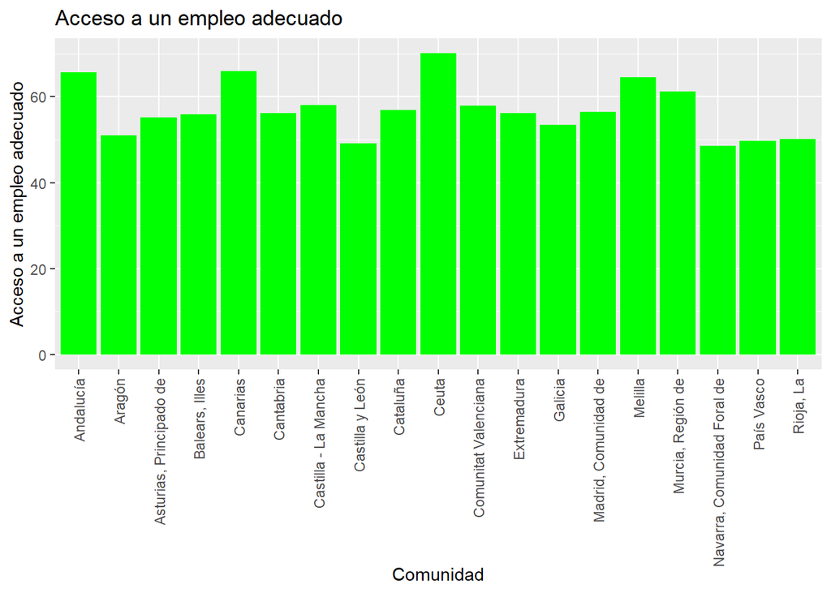

```r
library(tidyverse)
ggplot(data = Barreras_en_la_participación_social, aes(x = `Comunidad`, y = `Acceso a un empleo adecuado`)) +  geom_bar(stat="identity", position="stack", fill="green") + ggtitle("Acceso a un empleo adecuado ") + theme(axis.text.x = element_text(angle = 90, vjust = 0.5, hjust=1))
```

Con respecto a las barreras en el acceso a un empleo adecuado la Comunidad Foral de Navarra vuelve a presentar el índice más bajo, mientras que en este caso Ceuta es la que tiene mayor proporción. Lo que indicaría que Navarra en la comunidad con menos barreras sociales para las persoans discapacitadas encuanto a acceder a un empleo adecuado. En este caso puede deverse a diversos factores, como la facilidad a solicitar dichos trabajos, guardar plazas específicas para las personas con dificultades como estas, subenciones para que las empresas puedan ofrecer trabajos a personas con discapacidad…

```r
summary(Barreras_en_la_participación_social $`Uso de internet`, na.rm = TRUE)
```

```
##    Min. 1st Qu.  Median    Mean 3rd Qu.    Max.
##   20.17   21.88   24.81   24.89   27.87   31.14
```

```r
Barreras_en_la_participación_social$`Comunidad`[as.double(Barreras_en_la_participación_social $`Uso de internet`)== min(as.double(Barreras_en_la_participación_social $`Uso de internet`), na.rm = TRUE)]
```

```
## [1] "País Vasco"
```

```r
Barreras_en_la_participación_social$`Comunidad`[as.double(Barreras_en_la_participación_social$ `Uso de internet`) == max(as.double(Barreras_en_la_participación_social$`Uso de internet`), na.rm = TRUE)]
```

```
## [1] "Melilla"
```

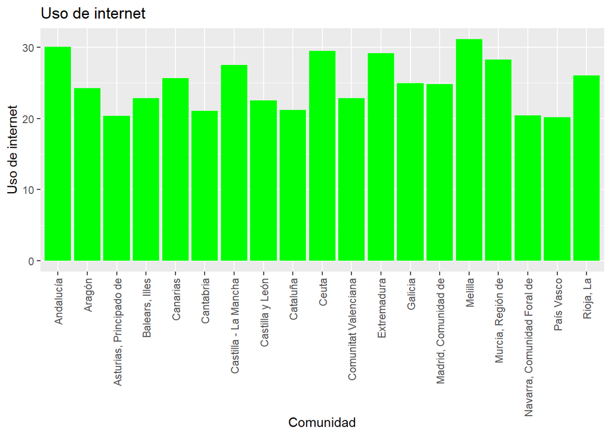

```r
library(tidyverse)
ggplot(data = Barreras_en_la_participación_social, aes(x = `Comunidad`, y = `Uso de internet`)) + geom_bar(stat="identity", position="stack", fill="green") + ggtitle("Uso de internet") + theme(axis.text.x = element_text(angle = 90, vjust = 0.5, hjust=1))
```

Con respecto a las barreras del uso de internet el País Vasco presenta el índice más bajo, mientras que Melilla es la que tiene mayor proporción. En conclisión el País vasco será la comuidad con menos barreras para que las personas con dicapacidad puedan usar el internet como cualquier otra persona. Esto puede deberse a algún tipo de ayuda que pueda tener la comunidad para evitar este tipo de dificultades en sus vidas.

```r
summary(Barreras_en_la_participación_social $`Contacto y apoyo social`, na.rm = TRUE)
```

```
##    Min. 1st Qu.  Median    Mean 3rd Qu.    Max.
##   1.440   3.670   4.270   4.423   5.600   7.210
```

```r
Barreras_en_la_participación_social$`Comunidad`[as.double(Barreras_en_la_participación_social $`Contacto y apoyo social`)== min(as.double(Barreras_en_la_participación_social $`Contacto y apoyo social`), na.rm = TRUE)]
```

```
## [1] "Extremadura"
```

```r
Barreras_en_la_participación_social$`Comunidad`[as.double(Barreras_en_la_participación_social$`Contacto y apoyo social`) == max(as.double(Barreras_en_la_participación_social$`Contacto y apoyo social`), na.rm = TRUE)]
```

```
## [1] "Melilla"
```

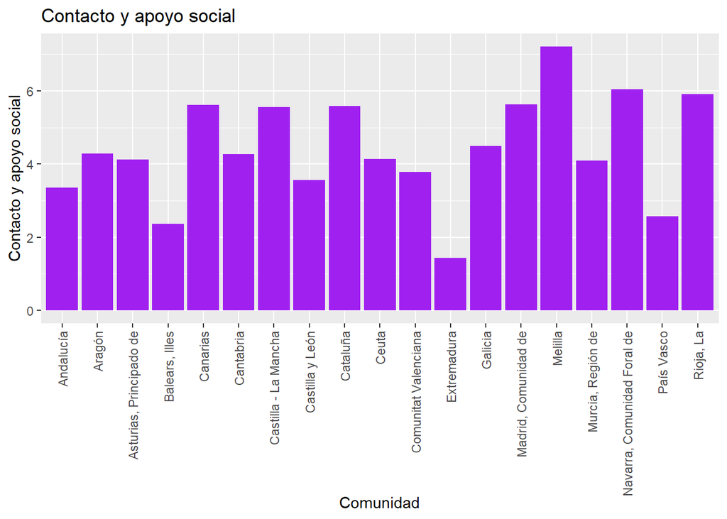

```r
library(tidyverse)
ggplot(data = Barreras_en_la_participación_social, aes(x = `Comunidad`, y = `Contacto y apoyo social`)) +  geom_bar(stat="identity", position="stack", fill="purple") + ggtitle("Contacto y apoyo social ") + theme(axis.text.x = element_text(angle = 90, vjust = 0.5, hjust=1))
```

Con respecto a las barreras en el contacto y apoyo social Extremadura presenta el índice más bajo, mientras que Melilla es la que tiene mayor proporción.

```r
summary(Barreras_en_la_participación_social $`Actividades de ocio y culturales`, na.rm = TRUE)
```

```
##    Min. 1st Qu.  Median    Mean 3rd Qu.    Max.
##   62.40   67.77   70.97   71.18   75.08   78.70
```

```r
Barreras_en_la_participación_social$`Comunidad`[as.double(Barreras_en_la_participación_social $`Actividades de ocio y culturales`)== min(as.double(Barreras_en_la_participación_social $`Actividades de ocio y culturales`), na.rm = TRUE)]
```

```
## [1] "Melilla"
```

```r
Barreras_en_la_participación_social$`Comunidad`[as.double(Barreras_en_la_participación_social$`Actividades de ocio y culturales`) == max(as.double(Barreras_en_la_participación_social$`Actividades de ocio y culturales`), na.rm = TRUE)]
```

```
## [1] "Andalucía"
```

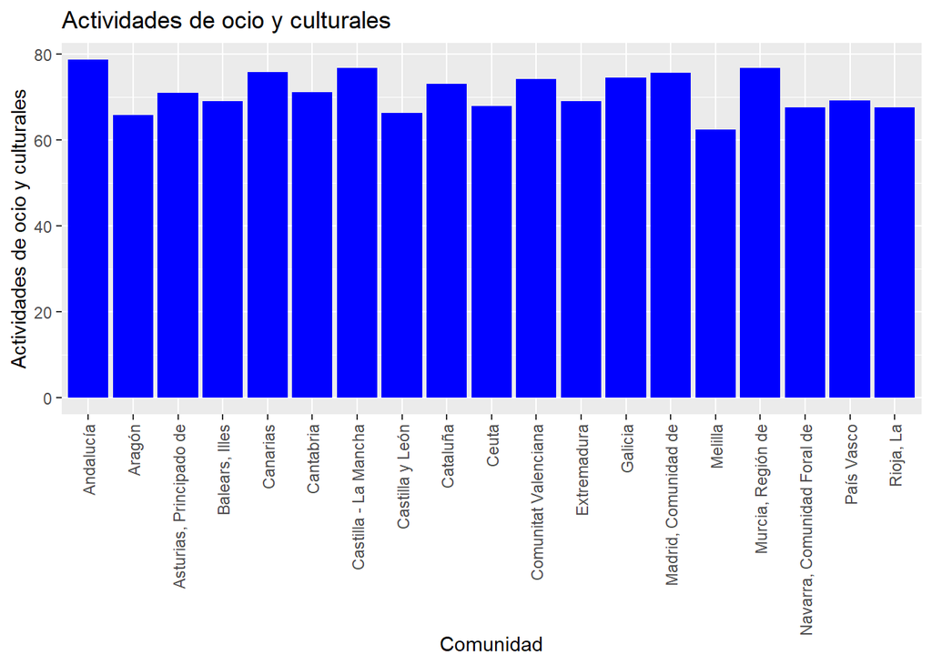

```r
library(tidyverse)
ggplot(data = Barreras_en_la_participación_social, aes(x = `Comunidad`, y = `Actividades de ocio y culturales`)) +  geom_bar(stat="identity", position="stack", fill="blue") + ggtitle("Actividades de ocio y culturales ") + theme(axis.text.x = element_text(angle = 90, vjust = 0.5, hjust=1))
```

Con respecto a las barreras que pueden ocasionar las actividades de ocio y culturales Melilla presenta el índice más bajo, mientras que Andalucía es la que tiene mayor proporción. La facilidad para que las personas con discapacidad puedan realizar actividades de ocio y culturales, puede deverse a diversos factores, entre ellos, las subenciones que puedan obetener, las instalaciones de los recintos en los que se vayan a celebrar dichas actividades ect. Y grácias a los datos, podemos saber que Melilla será quine más facilidades les de en este ambito, disminuyendo así la barrera social.

```r
summary(Barreras_en_la_participación_social $`Situación económica`, na.rm = TRUE)
```

```
##    Min. 1st Qu.  Median    Mean 3rd Qu.    Max.
##   26.40   36.65   41.46   40.16   43.31   52.92
```

```r
Barreras_en_la_participación_social$`Comunidad`[as.double(Barreras_en_la_participación_social $`Situación económica`)== min(as.double(Barreras_en_la_participación_social $`Situación económica`), na.rm = TRUE)]
```

```
## [1] "País Vasco"
```

```r
Barreras_en_la_participación_social$`Comunidad`[as.double(Barreras_en_la_participación_social$`Situación económica`) == max(as.double(Barreras_en_la_participación_social$`Situación económica`), na.rm = TRUE)]
```

```
## [1] "Andalucía"
```

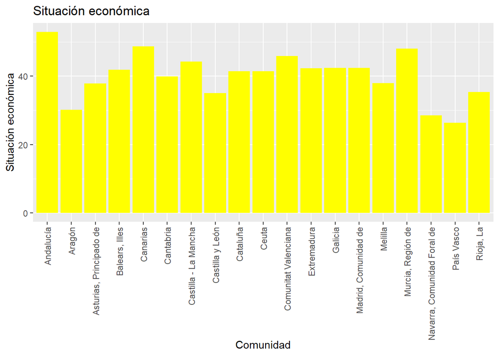

```r
library(tidyverse)
ggplot(data = Barreras_en_la_participación_social, aes(x = `Comunidad`, y = `Situación económica`)) +  geom_bar(stat="identity", position="stack", fill="yellow") + ggtitle("Situación económica") + theme(axis.text.x = element_text(angle = 90, vjust = 0.5, hjust=1))
```

Con respecto a las barreras en la situación económica el País Vasco presenta el índice más bajo, mientras que Andalucía es la que tiene mayor proporción. Esto es, el País Vasco es la comunidad que más ayuda o se implica en la situación económica de las personas con dicapacidad.

```r
summary(Barreras_en_la_participación_social $`Discriminación`, na.rm = TRUE)
```

```
##    Min. 1st Qu.  Median    Mean 3rd Qu.    Max.
##    9.19   10.48   12.23   12.36   14.01   16.64
```

```r
Barreras_en_la_participación_social$`Comunidad`[as.double(Barreras_en_la_participación_social $`Discriminación`)== min(as.double(Barreras_en_la_participación_social $`Discriminación`), na.rm = TRUE)]
```

```
## [1] "Galicia"
```

```r
Barreras_en_la_participación_social$`Comunidad`[as.double(Barreras_en_la_participación_social$`Discriminación`) == max(as.double(Barreras_en_la_participación_social$`Discriminación`), na.rm = TRUE)]
```

```
## [1] "Rioja, La"
```

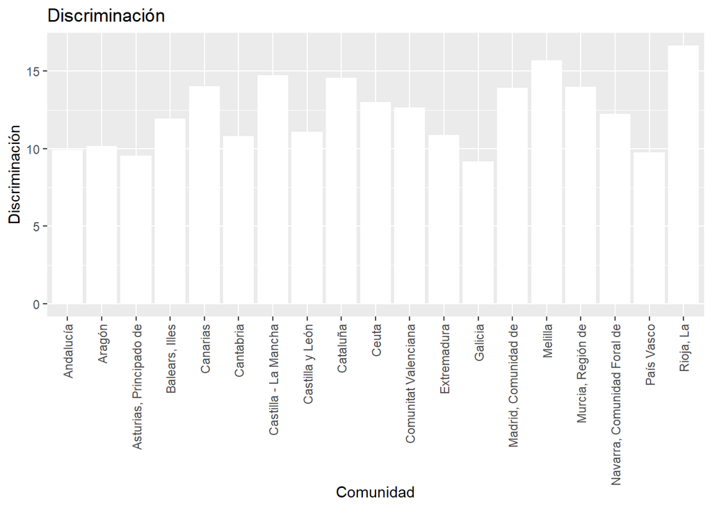

```r
library(tidyverse)
ggplot(data = Barreras_en_la_participación_social, aes(x = `Comunidad`, y = `Discriminación`)) +  geom_bar(stat="identity", position="stack", fill="white") + ggtitle("Discriminación ") + theme(axis.text.x = element_text(angle = 90, vjust = 0.5, hjust=1))
```

Con respecto a las barreras sociales en la discriminación Galicia presenta el índice más bajo, mientras que la Rioja es la que tiene mayor proporción.

- **Conclusiones barreras en la participación social**

Observando todos los datos obtenido y sobre todo las gráficas de cada tipo de barrera social. Hemos podido observar qeu a pesar de que las barreras sociales en general sean muy similares en todas las comunidades analizadas, siemrpe hay alguna comunidad que destaca con el bajo indice de dichas barreras, lo cual indica qeu si otras comunidades han podido bajar ese indice en general todas las comunidades podrian llegar al mismo nivel. Evitando así o, al menos, disminuyendo las barreras sociales con las que tienen que lidiar las personas con dicapacidad. Sabiendo que su día a día ya de por si es más compleja que el de resto de personas, las barreras sociales tendrían que ser mínimas en todas las comunidades, no ser un impedimento más en su vida diaria.

#### Discriminación discapacitados.

```r
library(readxl)
Discriminacion <- read_excel("DATA/Discriminacion.xlsx")
View(Discriminacion)
```

Vamos a analizar las dimensiones de este set de datos.

```r
dim(Discriminacion)
```

```
## [1] 19  4
```

Las dimensiones de este set de datos es de 19 files y 4 columnas. 19 filas correspondientes a las 17 ciudades autónomas y las dos ciudades autónomas que componen España. 4 columnas, una perteneciente a las comuninadades, otra al sexo masculina, otra al femenino y una última perteneciente a ambos sexos.

```r
class(Discriminacion)
```

```
## [1] "tbl_df"     "tbl"        "data.frame"
```

Para poder realizar el análisis de los datos vamos a transformar todos los nombres de las columnas con “make.names” para cumplan las reglas sintácticas. Vamos a realizar este proceso para las columnas “AMBOS_SEXOS”, “HOMBRES”, y “MUJERES”.

1. Columna AMBOS_SEXOS

```r
make.names(Discriminacion)
```

```
## [1] "c..Andalucía....Aragón....Asturias..Principado.de....Balears..Illes....Canarias....Cantabria....Castilla.y.León....Castilla...La.Mancha....Cataluña....Comunitat.Valenciana....Extremadura....Galicia....Madrid..Comunidad.de....Murcia..Región.de....Navarra..Comunidad.Foral.de....País.Vasco....R…
## [2] "c.9.94..10.15..9.56..11.94..14.02..10.82..11.07..14.74..14.55..12.65..10.88..9.19..13.93..13.99..12.23..9.77..16.64..12.99..15.69."
## [3] "c.7.56..5.83..8.74..12.88..9.5..9.21..8.83..11.81..11.95..12.75..8.99..6.02..11.17..10.61..7.38..8.79..13.92..2.34..15.51."
## [4] "c.12.23..14.38..10.3..11.01..18.45..12.35..13.25..17.71..17.03..12.55..12.73..12.11..16.43..17.37..17..10.69..19.3..23.5..15.9."
```

```r
Discriminacion$AMBOS_SEXOS
```

```
##  [1]  9.94 10.15  9.56 11.94 14.02 10.82 11.07 14.74 14.55 12.65 10.88  9.19
## [13] 13.93 13.99 12.23  9.77 16.64 12.99 15.69
```

```r
is.double(Discriminacion$AMBOS_SEXOS)
```

```
## [1] TRUE
```

```r
typeof(Discriminacion$AMBOS_SEXOS)
```

```
## [1] "double"
```

2. Columna HOMBRES

```r
make.names(Discriminacion)
```

```
## [1] "c..Andalucía....Aragón....Asturias..Principado.de....Balears..Illes....Canarias....Cantabria....Castilla.y.León....Castilla...La.Mancha....Cataluña....Comunitat.Valenciana....Extremadura....Galicia....Madrid..Comunidad.de....Murcia..Región.de....Navarra..Comunidad.Foral.de....País.Vasco....R…
## [2] "c.9.94..10.15..9.56..11.94..14.02..10.82..11.07..14.74..14.55..12.65..10.88..9.19..13.93..13.99..12.23..9.77..16.64..12.99..15.69."
## [3] "c.7.56..5.83..8.74..12.88..9.5..9.21..8.83..11.81..11.95..12.75..8.99..6.02..11.17..10.61..7.38..8.79..13.92..2.34..15.51."
## [4] "c.12.23..14.38..10.3..11.01..18.45..12.35..13.25..17.71..17.03..12.55..12.73..12.11..16.43..17.37..17..10.69..19.3..23.5..15.9."
```

```r
Discriminacion$HOMBRES
```

```
##  [1]  7.56  5.83  8.74 12.88  9.50  9.21  8.83 11.81 11.95 12.75  8.99  6.02
## [13] 11.17 10.61  7.38  8.79 13.92  2.34 15.51
```

```r
is.double(Discriminacion$HOMBRES)
```

```
## [1] TRUE
```

```r
typeof(Discriminacion$HOMBRES)
```

```
## [1] "double"
```

3. Columna MUJERES

```r
make.names(Discriminacion)
```

```
## [1] "c..Andalucía....Aragón....Asturias..Principado.de....Balears..Illes....Canarias....Cantabria....Castilla.y.León....Castilla...La.Mancha....Cataluña....Comunitat.Valenciana....Extremadura....Galicia....Madrid..Comunidad.de....Murcia..Región.de....Navarra..Comunidad.Foral.de....País.Vasco....R…
## [2] "c.9.94..10.15..9.56..11.94..14.02..10.82..11.07..14.74..14.55..12.65..10.88..9.19..13.93..13.99..12.23..9.77..16.64..12.99..15.69."
## [3] "c.7.56..5.83..8.74..12.88..9.5..9.21..8.83..11.81..11.95..12.75..8.99..6.02..11.17..10.61..7.38..8.79..13.92..2.34..15.51."
## [4] "c.12.23..14.38..10.3..11.01..18.45..12.35..13.25..17.71..17.03..12.55..12.73..12.11..16.43..17.37..17..10.69..19.3..23.5..15.9."
```

```r
Discriminacion$MUJERES
```

```
##  [1] 12.23 14.38 10.30 11.01 18.45 12.35 13.25 17.71 17.03 12.55 12.73 12.11
## [13] 16.43 17.37 17.00 10.69 19.30 23.50 15.90
```

```r
is.double(Discriminacion$MUJERES)
```

```
## [1] TRUE
```

```r
typeof(Discriminacion$MUJERES)
```

```
## [1] "double"
```

*Vamos a ir analizando cada columna*

**Columna “AMBOS_SEXOS”"**

*Media y mediana*

```r
mean(as.double(Discriminacion$AMBOS_SEXOS), na.rm = TRUE)
```

```
## [1] 12.35526
```

La media del número de discriminación en ambos sexos por comunidad y/o ciudad autónoma es 12.35526

```r
median(as.double(Discriminacion$AMBOS_SEXOS), na.rm = TRUE)
```

```
## [1] 12.23
```

La medina del número de discriminación en ambos sexos por comunidad y/o ciudad autónoma es 12.23

La mediana de los datos demográficos no se distancia mucho de la media, por lo que no debería de haber datos muy extremos.

- **Cálculo conjunto de varias medidas estadísticas (summary)**

```r
summary(as.double(Discriminacion$AMBOS_SEXOS), na.rm = TRUE)
```

```
##    Min. 1st Qu.  Median    Mean 3rd Qu.    Max.
##    9.19   10.48   12.23   12.36   14.01   16.64
```

El mínimo es: 9.19

El máximo es: 16.64

El primer cuartil es: 10.48

El tercer cuartil es: 14.01

La mediana: 12.23

La media es: 12.36

El máximo corresponde a la comunidad La Rioja.

**Columna “HOMBRES”"**

*Media y mediana*

```r
mean(as.double(Discriminacion$HOMBRES), na.rm = TRUE)
```

```
## [1] 9.673158
```

La media del número total de discriminación en hombres por comunidad y/o ciudad autónoma es 9.673158

```r
median(as.double(Discriminacion$HOMBRES), na.rm = TRUE)
```

```
## [1] 9.21
```

La medina del número de discrimanción en hombres por comunidad y/o ciudad autónoma es 9.21

La mediana de los datos demográficos no se distancia mucho de la media, por lo que no debería de haber datos muy extremos.

- **Cálculo conjunto de varias medidas estadísticas (summary)**

```r
summary(as.double(Discriminacion$HOMBRES), na.rm = TRUE)
```

```
##    Min. 1st Qu.  Median    Mean 3rd Qu.    Max.
##   2.340   8.150   9.210   9.673  11.880  15.510
```

El mínimo es: 2.34

El máximo es: 15.51

El primer cuartil es: 8.150

El tercer cuartil es: 11.88

La mediana: 9.21

La media es: 9.673

El mínimo corresponde a la ciudad de Ceuta. El máximo corresponde a la ciudad de Melilla.

**Columna “MUJERES”"**

*Media y mediana*

```r
mean(as.double(Discriminacion$MUJERES), na.rm = TRUE)
```

```
## [1] 14.96263
```

La media del número de discriminación en mujeres por comunidad y/o ciudad autónoma es 14.96263

```r
median(as.double(Discriminacion$MUJERES), na.rm = TRUE)
```

```
## [1] 14.38
```

La mediana del número de discriminación en mujeres por comunidad y/o ciudad autónoma es 14.38

La mediana de los datos demográficos no se distancia mucho de la media, por lo que no debería de haber datos muy extremos.

- **Cálculo conjunto de varias medidas estadísticas (summary)**

```r
summary(as.double(Discriminacion$MUJERES), na.rm = TRUE)
```

```
##    Min. 1st Qu.  Median    Mean 3rd Qu.    Max.
##   10.30   12.29   14.38   14.96   17.20   23.50
```

El mínimo es: 10.3

El máximo es: 23.5

El primer cuartil es: 12.29

El tercer cuartil es: 17.2

La mediana: 14.38

La media es: 14.96

El mínimo corresponde a la comunidad de Asturias en esto puede influir que Asturias tiene el menor dato demográfico. El máximo corresponde a la ciudad de Ceuta.Esta ciudad encabeza limitaciones para ocuparse de los trámites administrativos diarios, con mayor insatisfación con el entorno. Este dato choca bastante con que en el análisis anterior hemos comprado que la ciudad/comunidad autónoma con menor indice de discapacidad en hombres es Ceuta esto puede deberse a la discriminación por sexo que sufren las mujeres y no los hombres.

#### Conclusiones relación entre la discapacidad y el entorno en el que viven.

1. La calidad de vida, la satisfacción con el entorno y la esperanza de vida es mayor en comunidades con **mayor poder adquisitivo**, generalmente situadas en el norte de España.

2. La **proporción de discapacitados** no presenta diferencias entre pueblos y ciudades, pero la gravedad y la asistencia clínica de las discapacidades si es diferente en función de la comunidad. La diferencia proviene mayoritariamente de la **calidad del servicio sanitario**, siendo la mejor de todas Navarra. Por ello, podemos sacar como conclusión la idea de que existe una relación entre la gravedad de las patologías y la economía de los discapacitados.

*Unión entre tabla de los tipos de discapacidad (discapacidad severa) y economia de los discapacitados*

```r
Select_Discapacidad_y_Autonomia_personal <- Discapacidad_y_Autonomia_personal %>%
  select(`Comunidad`, `Tasa de discapacidad severa`) %>%
  mutate(`Porcentaje tasa discapacidad severa`= `Tasa de discapacidad severa`*100)

Select_Discapacidad_y_Autonomia_personal <- Select_Discapacidad_y_Autonomia_personal %>%
  select(`Comunidad`, `Porcentaje tasa discapacidad severa`)

Select_Discapacidad_y_Autonomia_personal
```

```
## # A tibble: 19 x 2
##    Comunidad                   `Porcentaje tasa discapacidad severa`
##    <chr>                                                       <dbl>
##  1 Andalucía                                                    4.82
##  2 Aragón                                                       4.15
##  3 Asturias, Principado de                                      3.65
##  4 Balears, Illes                                               6.25
##  5 Canarias                                                     4.78
##  6 Cantabria                                                    4.49
##  7 Castilla y León                                              3.33
##  8 Castilla - La Mancha                                         3.51
##  9 Cataluña                                                     4.77
## 10 Comunitat Valenciana                                         5.53
## 11 Extremadura                                                  4.37
## 12 Galicia                                                      5.52
## 13 Madrid, Comunidad de                                         1.94
## 14 Murcia, Región de                                            3.76
## 15 Navarra, Comunidad Foral de                                  3.24
## 16 País Vasco                                                   3.73
## 17 Rioja, La                                                    3.05
## 18 Ceuta                                                        6.54
## 19 Melilla                                                      6.84
```

```r
Select_Economia_discapacitados <- Economia_discapacitados %>%
              select(`Comunidad`, `Con dificultades para pagar las cosas esenciales`)

Select_Economia_discapacitados
```

```
## # A tibble: 19 x 2
##    Comunidad                   `Con dificultades para pagar las cosas esenciale~
##    <chr>                                                                   <dbl>
##  1 Andalucía                                                                52.9
##  2 Aragón                                                                   30.2
##  3 Asturias, Principado de                                                  37.9
##  4 Balears, Illes                                                           41.9
##  5 Canarias                                                                 48.7
##  6 Cantabria                                                                39.9
##  7 Castilla y León                                                          35.1
##  8 Castilla - La Mancha                                                     44.2
##  9 Cataluña                                                                 41.4
## 10 Comunitat Valenciana                                                     45.8
## 11 Extremadura                                                              42.3
## 12 Galicia                                                                  42.4
## 13 Madrid, Comunidad de                                                     42.4
## 14 Murcia, Región de                                                        48.0
## 15 Navarra, Comunidad Foral de                                              28.5
## 16 País Vasco                                                               26.4
## 17 Rioja, La                                                                35.4
## 18 Ceuta                                                                    41.5
## 19 Melilla                                                                  37.9
```

```r
Relacion_gravedad_economia <- full_join(x = Select_Discapacidad_y_Autonomia_personal, y = Select_Economia_discapacitados, by = "Comunidad")

Relacion_gravedad_economia
```

```
## # A tibble: 19 x 3
##    Comunidad                   `Porcentaje tasa disca~ `Con dificultades para p~
##    <chr>                                         <dbl>                     <dbl>
##  1 Andalucía                                      4.82                      52.9
##  2 Aragón                                         4.15                      30.2
##  3 Asturias, Principado de                        3.65                      37.9
##  4 Balears, Illes                                 6.25                      41.9
##  5 Canarias                                       4.78                      48.7
##  6 Cantabria                                      4.49                      39.9
##  7 Castilla y León                                3.33                      35.1
##  8 Castilla - La Mancha                           3.51                      44.2
##  9 Cataluña                                       4.77                      41.4
## 10 Comunitat Valenciana                           5.53                      45.8
## 11 Extremadura                                    4.37                      42.3
## 12 Galicia                                        5.52                      42.4
## 13 Madrid, Comunidad de                           1.94                      42.4
## 14 Murcia, Región de                              3.76                      48.0
## 15 Navarra, Comunidad Foral de                    3.24                      28.5
## 16 País Vasco                                     3.73                      26.4
## 17 Rioja, La                                      3.05                      35.4
## 18 Ceuta                                          6.54                      41.5
## 19 Melilla                                        6.84                      37.9
```

```r
Pivot_gravedad_economia <- pivot_longer(data = Relacion_gravedad_economia, names_to = "Variables", values_to = "Valores", cols = c( `Porcentaje tasa discapacidad severa`:`Con dificultades para pagar las cosas esenciales`))

Pivot_gravedad_economia
```

```
## # A tibble: 38 x 3
##    Comunidad               Variables                                     Valores
##    <chr>                   <chr>                                           <dbl>
##  1 Andalucía               Porcentaje tasa discapacidad severa              4.82
##  2 Andalucía               Con dificultades para pagar las cosas esenci~   52.9
##  3 Aragón                  Porcentaje tasa discapacidad severa              4.15
##  4 Aragón                  Con dificultades para pagar las cosas esenci~   30.2
##  5 Asturias, Principado de Porcentaje tasa discapacidad severa              3.65
##  6 Asturias, Principado de Con dificultades para pagar las cosas esenci~   37.9
##  7 Balears, Illes          Porcentaje tasa discapacidad severa              6.25
##  8 Balears, Illes          Con dificultades para pagar las cosas esenci~   41.9
##  9 Canarias                Porcentaje tasa discapacidad severa              4.78
## 10 Canarias                Con dificultades para pagar las cosas esenci~   48.7
## # ... with 28 more rows
```

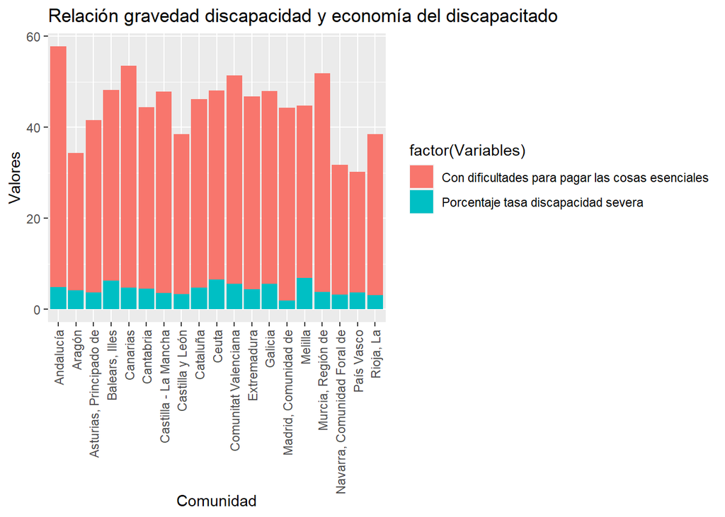

```r
ggplot(data = Pivot_gravedad_economia, aes(x = `Comunidad`, y = `Valores`)) +  geom_bar(stat="identity", position="stack", aes(fill = factor(Variables))) + ggtitle("Relación gravedad discapacidad y economía del discapacitado") + theme(axis.text.x = element_text(angle = 90, vjust = 0.5, hjust=1))
```

Nosotras pensamos que no solo es competencia de los amigos y familiares empatizar con una persona discapcitada y dedicarla tiempo, sino que la sociedad en su conjunto debe favorecer a que puedan hacer planes tranquilos que cualquier realizamos a diario como ir a tomar un café.

También nos gustaría reseñar que los discapacitados muchas veces padecen trastornos psicológicos como consecuencia de su situación, al ver transformada toda su vida. Todos deberíamos esforzarnos por crear una sociedad donde no se sientan desplazados, y rebajar así la incidencia de patologías como la depresión.

*Unión entre limitaciones cotidianas y discriminación social*

```r
Select_Limitaciones_domesticas <- Limitaciones_vida_cotidiana %>%
  select(`Comunidad`, `Para realizar tareas domésticas`)

Select_Limitaciones_domesticas
```

```
## # A tibble: 19 x 2
##    Comunidad                   `Para realizar tareas domésticas`
##    <chr>                                                   <dbl>
##  1 Andalucía                                                5.91
##  2 Aragón                                                   6.93
##  3 Asturias, Principado de                                  4.96
##  4 Balears, Illes                                           3.01
##  5 Canarias                                                 6.11
##  6 Cantabria                                                5.84
##  7 Castilla y León                                          5.02
##  8 Castilla - La Mancha                                     7.03
##  9 Cataluña                                                 6.17
## 10 Comunitat Valenciana                                     5.83
## 11 Extremadura                                              4.6
## 12 Galicia                                                  7.1
## 13 Madrid, Comunidad de                                     4.66
## 14 Murcia, Región de                                        6.86
## 15 Navarra, Comunidad Foral de                              4.11
## 16 País Vasco                                               5.89
## 17 Rioja, La                                                5.83
## 18 Ceuta                                                    6.38
## 19 Melilla                                                  5.55
```

```r
Select_Discriminacion <- Discriminacion %>%
  select(`Comunidad`, `AMBOS_SEXOS`)

Select_Discriminacion
```

```
## # A tibble: 19 x 2
##    Comunidad                   AMBOS_SEXOS
##    <chr>                             <dbl>
##  1 Andalucía                          9.94
##  2 Aragón                            10.2
##  3 Asturias, Principado de            9.56
##  4 Balears, Illes                    11.9
##  5 Canarias                          14.0
##  6 Cantabria                         10.8
##  7 Castilla y León                   11.1
##  8 Castilla - La Mancha              14.7
##  9 Cataluña                          14.6
## 10 Comunitat Valenciana              12.6
## 11 Extremadura                       10.9
## 12 Galicia                            9.19
## 13 Madrid, Comunidad de              13.9
## 14 Murcia, Región de                 14.0
## 15 Navarra, Comunidad Foral de       12.2
## 16 País Vasco                         9.77
## 17 Rioja, La                         16.6
## 18 Ceuta                             13.0
## 19 Melilla                           15.7
```

```r
Relacion_limitacion_discriminacion <- full_join(x = Select_Limitaciones_domesticas, y = Select_Discriminacion, by = "Comunidad")

Relacion_limitacion_discriminacion
```

```
## # A tibble: 19 x 3
##    Comunidad                   `Para realizar tareas domésticas` AMBOS_SEXOS
##    <chr>                                                   <dbl>       <dbl>
##  1 Andalucía                                                5.91        9.94
##  2 Aragón                                                   6.93       10.2
##  3 Asturias, Principado de                                  4.96        9.56
##  4 Balears, Illes                                           3.01       11.9
##  5 Canarias                                                 6.11       14.0
##  6 Cantabria                                                5.84       10.8
##  7 Castilla y León                                          5.02       11.1
##  8 Castilla - La Mancha                                     7.03       14.7
##  9 Cataluña                                                 6.17       14.6
## 10 Comunitat Valenciana                                     5.83       12.6
## 11 Extremadura                                              4.6        10.9
## 12 Galicia                                                  7.1         9.19
## 13 Madrid, Comunidad de                                     4.66       13.9
## 14 Murcia, Región de                                        6.86       14.0
## 15 Navarra, Comunidad Foral de                              4.11       12.2
## 16 País Vasco                                               5.89        9.77
## 17 Rioja, La                                                5.83       16.6
## 18 Ceuta                                                    6.38       13.0
## 19 Melilla                                                  5.55       15.7
```

```r
Pivot_limitacion_discriminacion <- pivot_longer(data = Relacion_limitacion_discriminacion, names_to = "Variables", values_to = "Valores", cols = c( `Para realizar tareas domésticas`:`AMBOS_SEXOS`))

Pivot_limitacion_discriminacion
```

```
## # A tibble: 38 x 3
##    Comunidad               Variables                       Valores
##    <chr>                   <chr>                             <dbl>
##  1 Andalucía               Para realizar tareas domésticas    5.91
##  2 Andalucía               AMBOS_SEXOS                        9.94
##  3 Aragón                  Para realizar tareas domésticas    6.93
##  4 Aragón                  AMBOS_SEXOS                       10.2
##  5 Asturias, Principado de Para realizar tareas domésticas    4.96
##  6 Asturias, Principado de AMBOS_SEXOS                        9.56
##  7 Balears, Illes          Para realizar tareas domésticas    3.01
##  8 Balears, Illes          AMBOS_SEXOS                       11.9
##  9 Canarias                Para realizar tareas domésticas    6.11
## 10 Canarias                AMBOS_SEXOS                       14.0
## # ... with 28 more rows
```

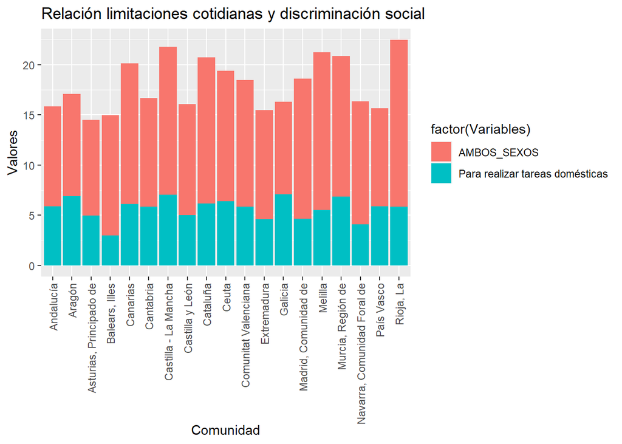

```r
ggplot(data = Pivot_limitacion_discriminacion, aes(x = `Comunidad`, y = `Valores`)) +  geom_bar(stat="identity", position="stack", aes(fill = factor(Variables))) + ggtitle("Relación limitaciones cotidianas y discriminación social") + theme(axis.text.x = element_text(angle = 90, vjust = 0.5, hjust=1))
```

4. No apreciamos ninguna relación considerable entre la satisfacción de las personas con el entorno en el que viven y las necesaidades sanitarias no satisfechas que contemplan. Hemos hecho una unión entre las dos tablas que tratan estos temas y no hay ningún patrón apreciable. Inicialmente sospechabamos que cuanto más grande sería la columna de satisfacción menor sería la de necesidades no satisfechas debido a que las personas damos mucha importancia a la salud en nuestra vida.

*Unión entre la tabla que muestra la satisfacción de los inviduos con e entorno donde viven y las necesidades no satisfechas a nivel sanitario de dichos inviduos.*

```r
Satisfacción_con_el_entorno <- dplyr::rename(.data = Satisfacción_con_el_entorno, Comunidad = `Total`)

Satisfacción_con_el_entorno
```

```
## # A tibble: 19 x 2
##    Comunidad                   Satisfacción
##    <chr>                              <dbl>
##  1 Andalucía                            7
##  2 Aragón                               7.6
##  3 Asturias, Principado de              7.7
##  4 Balears, Illes                       7.6
##  5 Canarias                             7.1
##  6 Cantabria                            7.6
##  7 Castilla y León                      7.4
##  8 Castilla-La Mancha                   7.4
##  9 Cataluña                             7.2
## 10 Comunitat Valenciana                 7.2
## 11 Extremadura                          7.3
## 12 Galicia                              6.6
## 13 Madrid, Comunidad de                 7.1
## 14 Murcia, Región de                    7
## 15 Navarra, Comunidad Foral de          7.8
## 16 País Vasco                           7.5
## 17 Rioja, La                            7.4
## 18 Ceuta                                6.3
## 19 Melilla                              6.8
```

```r
Necesidades_no_satisfechas <- dplyr::rename(.data = Necesidades_no_satisfechas, Comunidad = `Comunidades`)

Necesidades_no_satisfechas
```

```
## # A tibble: 19 x 2
##    Comunidad                   Necesidades
##    <chr>                             <dbl>
##  1 Andalucía                           0.5
##  2 Aragón                              0
##  3 Asturias, Principado de             0.2
##  4 Balears, Illes                      0.6
##  5 Canarias                            1.4
##  6 Cantabria                           0
##  7 Castilla y León                     0.3
##  8 Castilla - La Mancha                0.5
##  9 Cataluña                            0.3
## 10 Comunitat Valenciana                0.8
## 11 Extremadura                         0.1
## 12 Galicia                             0
## 13 Madrid, Comunidad de                0.4
## 14 Murcia, Región de                   0.2
## 15 Navarra, Comunidad Foral de         0.9
## 16 País Vasco                          0.1
## 17 Rioja, La                           0.1
## 18 Ceuta                               0
## 19 Melilla                             0
```

```r
Relacion_satisfaccion_necesidades <- full_join(x = Satisfacción_con_el_entorno, y = Necesidades_no_satisfechas, by = "Comunidad")

Relacion_satisfaccion_necesidades
```

```
## # A tibble: 20 x 3
##    Comunidad                   Satisfacción Necesidades
##    <chr>                              <dbl>       <dbl>
##  1 Andalucía                            7           0.5
##  2 Aragón                               7.6         0
##  3 Asturias, Principado de              7.7         0.2
##  4 Balears, Illes                       7.6         0.6
##  5 Canarias                             7.1         1.4
##  6 Cantabria                            7.6         0
##  7 Castilla y León                      7.4         0.3
##  8 Castilla-La Mancha                   7.4        NA
##  9 Cataluña                             7.2         0.3
## 10 Comunitat Valenciana                 7.2         0.8
## 11 Extremadura                          7.3         0.1
## 12 Galicia                              6.6         0
## 13 Madrid, Comunidad de                 7.1         0.4
## 14 Murcia, Región de                    7           0.2
## 15 Navarra, Comunidad Foral de          7.8         0.9
## 16 País Vasco                           7.5         0.1
## 17 Rioja, La                            7.4         0.1
## 18 Ceuta                                6.3         0
## 19 Melilla                              6.8         0
## 20 Castilla - La Mancha                NA           0.5
```

```r
Pivot_satisfaccion_necesidades <- pivot_longer(data = Relacion_satisfaccion_necesidades, names_to = "Variables", values_to = "Valores", cols = c( `Satisfacción`:`Necesidades`))

Pivot_satisfaccion_necesidades
```

```
## # A tibble: 40 x 3
##    Comunidad               Variables    Valores
##    <chr>                   <chr>          <dbl>
##  1 Andalucía               Satisfacción     7
##  2 Andalucía               Necesidades      0.5
##  3 Aragón                  Satisfacción     7.6
##  4 Aragón                  Necesidades      0
##  5 Asturias, Principado de Satisfacción     7.7
##  6 Asturias, Principado de Necesidades      0.2
##  7 Balears, Illes          Satisfacción     7.6
##  8 Balears, Illes          Necesidades      0.6
##  9 Canarias                Satisfacción     7.1
## 10 Canarias                Necesidades      1.4
## # ... with 30 more rows
```

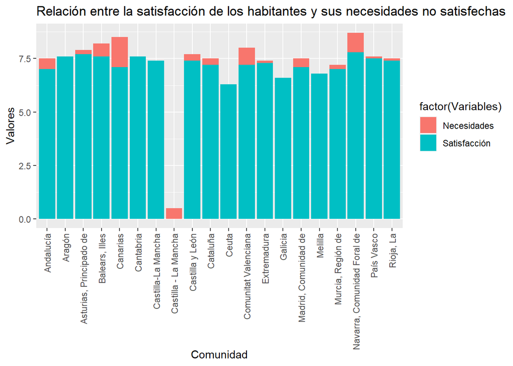

```r
ggplot(data = Pivot_satisfaccion_necesidades, aes(x = `Comunidad`, y = `Valores`)) +  geom_bar(stat="identity", position="stack", aes(fill = factor(Variables))) + ggtitle("Relación entre la satisfacción de los habitantes y sus necesidades no satisfechas") + theme(axis.text.x = element_text(angle = 90, vjust = 0.5, hjust=1))
```

```r
Select_Economia <- Economia_discapacitados %>%
  select(`Comunidad`, `Con dificultades para pagar las cosas esenciales`)

Select_Economia
```

```
## # A tibble: 19 x 2
##    Comunidad                   `Con dificultades para pagar las cosas esenciale~
##    <chr>                                                                   <dbl>
##  1 Andalucía                                                                52.9
##  2 Aragón                                                                   30.2
##  3 Asturias, Principado de                                                  37.9
##  4 Balears, Illes                                                           41.9
##  5 Canarias                                                                 48.7
##  6 Cantabria                                                                39.9
##  7 Castilla y León                                                          35.1
##  8 Castilla - La Mancha                                                     44.2
##  9 Cataluña                                                                 41.4
## 10 Comunitat Valenciana                                                     45.8
## 11 Extremadura                                                              42.3
## 12 Galicia                                                                  42.4
## 13 Madrid, Comunidad de                                                     42.4
## 14 Murcia, Región de                                                        48.0
## 15 Navarra, Comunidad Foral de                                              28.5
## 16 País Vasco                                                               26.4
## 17 Rioja, La                                                                35.4
## 18 Ceuta                                                                    41.5
## 19 Melilla                                                                  37.9
```

```r
Select_Cuidadores <- Cuidadores %>%
  select(`Comunidad`, `En el hogar de la persona que cuida`)

Select_Cuidadores
```

```
## # A tibble: 20 x 2
##    Comunidad                   `En el hogar de la persona que cuida`
##    <chr>                                                       <dbl>
##  1 Andalucía                                                  1280.
##  2 Aragón                                                      240.
##  3 Asturias, Principado de                                      45.1
##  4 Balears, Illes                                               40.2
##  5 Canarias                                                     22.9
##  6 Cantabria                                                    43
##  7 Castilla y León                                              18.8
##  8 Castilla - La Mancha                                         84.6
##  9 Cataluña                                                     61.8
## 10 Comunitat Valenciana                                        170.
## 11 Extremadura                                                 159.
## 12 Galicia                                                      32.9
## 13 Madrid, Comunidad de                                        128.
## 14 Murcia, Región de                                           105.
## 15 Navarra, Comunidad Foral de                                  40.3
## 16 País Vasco                                                   15
## 17 Rioja, La                                                    61.3
## 18 Ceuta                                                         7.9
## 19 Melilla                                                       2.5
## 20 <NA>                                                          2.6
```

```r
Relacion_cuidadores_economia <- full_join(x = Select_Economia, y = Select_Cuidadores, by = "Comunidad")

Relacion_cuidadores_economia
```

```
## # A tibble: 20 x 3
##    Comunidad                   `Con dificultades para pa~ `En el hogar de la pe~
##    <chr>                                            <dbl>                  <dbl>
##  1 Andalucía                                         52.9                 1280.
##  2 Aragón                                            30.2                  240.
##  3 Asturias, Principado de                           37.9                   45.1
##  4 Balears, Illes                                    41.9                   40.2
##  5 Canarias                                          48.7                   22.9
##  6 Cantabria                                         39.9                   43
##  7 Castilla y León                                   35.1                   18.8
##  8 Castilla - La Mancha                              44.2                   84.6
##  9 Cataluña                                          41.4                   61.8
## 10 Comunitat Valenciana                              45.8                  170.
## 11 Extremadura                                       42.3                  159.
## 12 Galicia                                           42.4                   32.9
## 13 Madrid, Comunidad de                              42.4                  128.
## 14 Murcia, Región de                                 48.0                  105.
## 15 Navarra, Comunidad Foral de                       28.5                   40.3
## 16 País Vasco                                        26.4                   15
## 17 Rioja, La                                         35.4                   61.3
## 18 Ceuta                                             41.5                    7.9
## 19 Melilla                                           37.9                    2.5
## 20 <NA>                                              NA                      2.6
```

```r
Pivot_cuidadores_economia <- pivot_longer(data = Relacion_cuidadores_economia, names_to = "Variables", values_to = "Valores", cols = c( `Con dificultades para pagar las cosas esenciales`:`En el hogar de la persona que cuida`))

Pivot_cuidadores_economia
```

```
## # A tibble: 40 x 3
##    Comunidad               Variables                                     Valores
##    <chr>                   <chr>                                           <dbl>
##  1 Andalucía               Con dificultades para pagar las cosas esenci~    52.9
##  2 Andalucía               En el hogar de la persona que cuida            1280.
##  3 Aragón                  Con dificultades para pagar las cosas esenci~    30.2
##  4 Aragón                  En el hogar de la persona que cuida             240.
##  5 Asturias, Principado de Con dificultades para pagar las cosas esenci~    37.9
##  6 Asturias, Principado de En el hogar de la persona que cuida              45.1
##  7 Balears, Illes          Con dificultades para pagar las cosas esenci~    41.9
##  8 Balears, Illes          En el hogar de la persona que cuida              40.2
##  9 Canarias                Con dificultades para pagar las cosas esenci~    48.7
## 10 Canarias                En el hogar de la persona que cuida              22.9
## # ... with 30 more rows
```

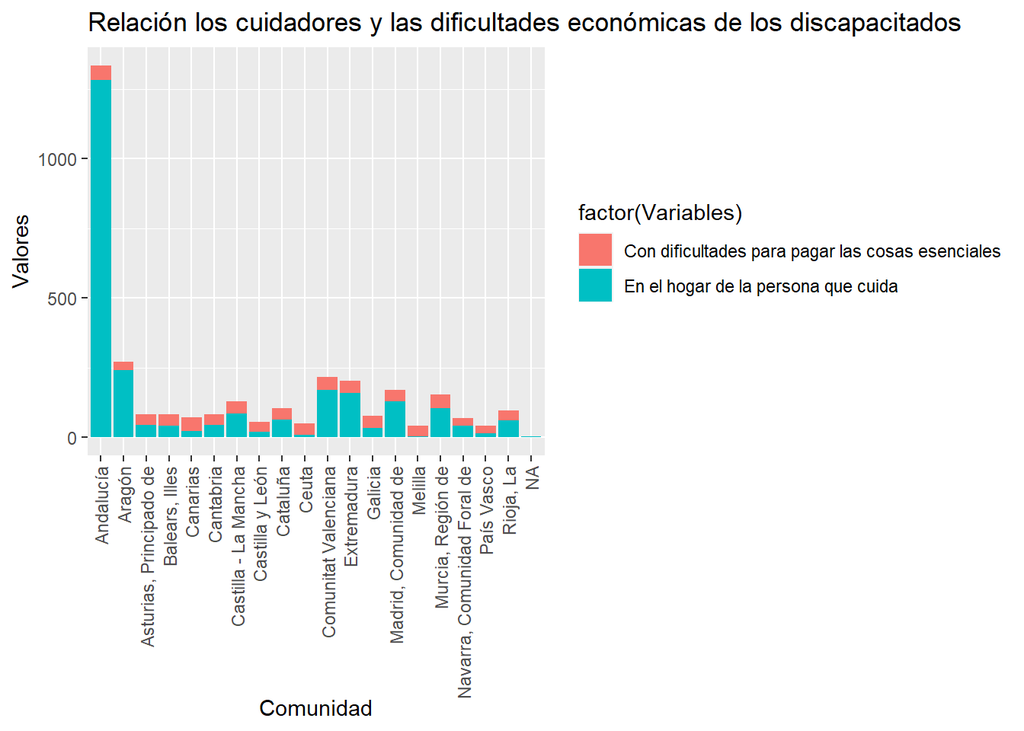

```r
ggplot(data = Pivot_cuidadores_economia, aes(x = `Comunidad`, y = `Valores`)) +  geom_bar(stat="identity", position="stack", aes(fill = factor(Variables))) + ggtitle("Relación los cuidadores y las dificultades económicas de los discapacitados") + theme(axis.text.x = element_text(angle = 90, vjust = 0.5, hjust=1))
```

## Conclusión final:

En primer lugar, parece ser que el entorno no tiene una gran implicación sobre la aparición de discapacidades.

Por otro lado, no vemos una diferencia clara entre la calidad del sistema sanitario de las comunidades más rurales y las más urbanas. Las comunidades con más cantidad de pueblos (Castilla y León) presentan mayor cantidad de consultorios pero esto no implica que sea un sistema sanitario de mejor calidad. De hecho sabemos que muchos consultorios rurales presentan una atención deficitaria porque están muy poco tiempo abiertos debido a las dificultades para sufragar costes tan elevados. De hecho si revisamos las noticias estatales de los últimos días veremos datos como los siguientes:

- [Escasa inversión en centros de salud en Huesca](https://www.heraldo.es/noticias/aragon/huesca/2021/12/10/la-diputacion-critica-la-muy-escasa-inversion-de-la-dga-en-los-centros-de-salud-de-huesca-y-barbastro-1539505.html/)
- [Abandono de atención primaria en Campoo](https://www.eldiarioalerta.com/articulo/campoo-los-valles/denuncian-abandono-atencion-primaria-campoo/20211209130608327206.html/)
- [Cierre consultorios en Zamora](https://www.laopiniondezamora.es/comarcas/2021/11/12/tabara-convoca-concentracion-cierre-consultorios-59430635.html/)

Pesé a estas situaciones nosotras no hemos apreciado estadísticamente más necesidades no satisfechas en el ámbito rural, así que no vamos a indagar más en el asunto. Solo mencionar que probablemente las personas con discapacidades más graves prefieran vivir en ciudades por la inmediatez de los servicios sanitarios, aunque no dudamos del efecto sanador de la tranquilidad de los pueblos.